# Complete research report

Skip to content

DLE Research Library

Research draft · Human review pending · Collection cutoffs September 14–16, 2026 · Review and scope

**On this page**

> **Research draft for source review.** The observations below have been checked by an AI assistant against source text, with selected source pages also inspected visually. No human review has yet been recorded. These observations remain provisional; the separate human-reviewed dataset contains no accepted rows. The report distinguishes technical-report estimates, company targets, reported test results, and agency decisions.

# US DLE project evidence

Explore US direct lithium extraction projects through public filings and technical reports. **18 research profiles**, including proposed developments, demonstrations and historical projects.

**Compare chemistry →** Concentrations, sample basis and full published analyses.

**Compare pretreatment →** Selected methods, tested alternatives and disclosure gaps.

**Browse flowsheets →** Published diagrams, water flows and process boundaries.

## Explore a project

Scroll within the table to see all columns and rows.

| Project | Location / feed context | Start here |
| --- | --- | --- |
| South West Arkansas | Arkansas · Smackover brine | Chemistry · Process |
| Waterleaf / Lilac | Utah · Great Salt Lake brine | Chemistry · Process |
| Hell’s Kitchen | California · Geothermal brine | Chemistry · Process |

**All 18 projects →** · Principal findings · Disclosure coverage

# Overview

This research draft brings together project-specific securities disclosures and environmental records for 18 US direct lithium extraction (DLE) project profiles, including development programs, historical demonstrations and suspended designs. The count is a set of research profiles, not 18 operating plants or independent companies. Its purpose is to make the evidence findable and comparable **where the definitions allow it**, while preserving disagreements and gaps. It does not establish present operating performance. **South West Arkansas and Hell’s Kitchen retain their September 14, 2026 collection cutoff; the other profiles use September 16, 2026.** A collection date is not the date of the underlying study.

**Collection:** 124 source records; 100 successful original-file downloads; 24 failed original-file downloads. The saved PDFs contain 6,562 pages. **Evidence:** 815 observations; 0 accepted after human review.

The source manifest covers official agency pages, submitted reports and attachments, agency decisions, SEC indexes and selected exhibits, and explicitly labeled issuer supplements. The saved SEC histories now contain **2,846 metadata entries**: 219 Standard Lithium, 79 Plum Acquisition Corp. IV, 2,453 Compass Minerals (April 2003–September 2026) and 95 EnergyX (November 2020–July 2026). Metadata is inventoried, not assumed to be downloaded or reviewed project evidence. D006, D007, D083, D084, D091.

## Project reports

Research profiles are grouped by project location, including foreign parent companies. They are not a count of operating plants. Dates and engineering scope are preserved within each profile.

Scroll within the table to see all columns and rows.

| Project / location | Available records and gaps | Technical views |
| --- | --- | --- |
| South West Arkansas · Lafayette and Columbia counties, Arkansas | full published pilot-feed composition, process flowsheets, project profile, sources and evidence. | Chemistry · Process · Evidence |
| Hell’s Kitchen · Imperial County, California | full expected brine composition, geothermal schematic, lithium-process disclosure limits, sources and evidence. | Chemistry · Process · Evidence |
| BHER demonstration · Imperial County, California | measured brine, canal-water and steam tables; process diagram; field-test outcome. | Chemistry · Process · Evidence |
| ATLiS · Imperial County, California | DOE block flowsheet, brine/water flows, reagent use and explicit chemistry gaps. | Chemistry · Process · Evidence |
| Ogden / Great Salt Lake · Utah | lake and pond chemistry, historical process design, and separate EnergyX proposal. | Chemistry · Process · Evidence |
| Green River · Utah | Anson/Blackstone permit chemistry, injection limits and stream-label discrepancy. | Chemistry · Process · Evidence |
| Waterleaf / Lilac · Box Elder County, Utah | pilot and 12-stream design chemistry, groundwater laboratory results, numbered flowsheet and public water summaries. | Chemistry · Process · Evidence |
| Franklin · Hopkins, Franklin and Titus counties, Texas | 2023 exploration-average chemistry, expected flowsheet and separate 2026 PEA assumptions. | Chemistry · Process · Evidence |
| Wellspring · North Dakota | North Dakota produced-water field program; grant records and high-level diagram. | Chemistry · Process · Evidence |
| Paradox · West of Moab, Grand County, Utah | draft permit chemistry with reused Green River ranges and unresolved stream labels. | Chemistry · Process · Evidence |
| US Magnesium · Utah | historical DLE installation and idling; limited government-survey evidence. | Chemistry · Process · Evidence |
| Mandrake Utah · San Juan County, Utah | resource-horizon concentrations and September 2026 bulk-sample appraisal update. | Chemistry · Process · Evidence |
| Evergreen · Southwest Arkansas | TETRA/Saltwerx unit history; direct lithium engineering records still needed. | Chemistry · Process · Evidence |
| Pine / Exxon · Miller and Lafayette counties, Arkansas | Exxon/Saltwerx unit identity; neighboring-property evidence with technical gaps. | Chemistry · Process · Evidence |
| Lonestar · Northeast Texas | Texas demonstration and mineral-option disclosures; chemistry package not established. | Chemistry · Process · Evidence |
| Daytona / Folsom Point · Southwest Arkansas | EnergyX Arkansas acquisition/development record; no dated feed assay established. | Chemistry · Process · Evidence |
| Magnolia · Magnolia, Arkansas | issuer-supported pilot record; direct project government package still needed. | Chemistry · Process · Evidence |
| LANXESS history · El Dorado, Arkansas | ended commercial arrangement and separate continuing demonstration evidence. | Chemistry · Process · Evidence |

## Principal findings

- **Pretreatment now has a dedicated comparison.** The all-project matrix distinguishes selected designs, tested alternatives and disclosure gaps; the method inventory and stream-boundary check keep feed preparation separate from eluate purification and discharge treatment.
- **The expanded report contains 18 profiles with uneven evidence.** Waterleaf adds six measured brine/eluate constituents, eleven design-ion rows across twelve numbered streams, and a separate groundwater laboratory panel; Franklin adds ten exploration-average brine constituents. Several additions establish project identity or history only, and Magnolia remains an explicitly issuer-supported profile. Disclosure comparison.
- **New concentrations retain their stream and date.** Waterleaf reports 69 mg/L raw-brine lithium and 2,044 mg/L in pilot eluate. Franklin reports 668 mg/L in 2023 exploration averages versus 515 mg/L as a 2026 PEA lifetime model average. Paradox repeats Green River’s proposed 170–210 ppm range; those tables are not independent assays. Waterleaf, Franklin, Paradox.
- **A process diagram is not a complete water balance.** Source diagrams cover BHER, ATLiS, historical Ogden, Waterleaf, Franklin and Wellspring. Waterleaf publishes a design water-summary table and a 12-stream chemistry/flow excerpt, while the full Appendix D.4 balance is redacted. BHER cancelled its completed-balance deliverable; none of these packages establishes all numbered streams with measured flows and compositions. BHER, ATLiS, Ogden.
- **The original pilot’s brine concentration figures have different bases.** SWA’s September 2025 plant-design table uses 439.9 mg/L lithium; HK’s August 2023 EIR gives 250 mg/L as expected geothermal brine composition. Neither is a directly comparable dated well assay. SWA separately reports well-sample results and changing concentrations in its production model. O009, O051, brine chemistry comparison.
- **Recovery needs a process boundary.** South West Arkansas reports greater than 95% lithium extraction in demonstration/pilot testing, while the commercial process design uses 89.25% overall brine-to-product recovery. These are different quantities. O002, O003.
- **Water figures need reconciliation.** The 2025 South West Arkansas feasibility study gives 3.17 million m³/year; the May 2026 DOE assessment gives 1,600–1,700 gpm for the central processing facility, after planned recycling. Hell’s Kitchen gives both 6,100 and 6,300 acre-feet/year for its lithium facility in different EIR sections. O016, O017, O055, O056.
- **Emissions estimates are not comparable as presented.** South West Arkansas’s estimate includes gas-fired electricity generation. Hell’s Kitchen’s combined net result includes credit for geothermal electricity displacing grid power. Neither number is a measured lithium-product carbon intensity. O033, O063.
- **Study vintage changes the story.** South West Arkansas’s earlier PFS describes lithium hydroxide monohydrate; its later DFS describes lithium carbonate. Its announced first-production target moved from 2027 in the earlier source to 2029 in the August 2026 announcement. O045, O048, O004, O044.
- **Permitting decisions have specific scope.** DOE’s FONSI addresses its funding action. Hell’s Kitchen’s county decisions concern specified project entitlements. These records do not demonstrate that every authorization has been obtained, that litigation is resolved, or that commercial operations have begun. O042, O065, O066.

## How to read the report

Start with a project or a dedicated chemistry, pretreatment or flowsheet comparison. Use each **O-number** to reach the full observation, and each **D-number** to reach the document catalog. Observation links identify a printed page, section, table, or slide; PDF citations also include the physical PDF page number, which may differ from printed pagination.

On narrow screens, scroll wide tables sideways to read the remaining columns. The pretreatment comparison covers all 18 project profiles.

**Reported measurement** means the source reports a test result; it is not independent verification by this pilot. **Design/model estimate** means an engineering or economic assumption. **Company target** means a forward-looking statement. **Agency decision** is confined to the named action. **Not located** is a bounded search outcome, not a claim that information does not exist.

# Project profiles

## South West Arkansas

The project is developed through **SWA Lithium LLC**, associated with Standard Lithium and Equinor under the Smackover Lithium name. The Reynolds Brine Unit and the central processing facility belong to the commercial project considered here. Standard Lithium’s demonstration plant at the LANXESS South site provides supporting test evidence; the LANXESS Phase 1A commercial project and East Texas projects are separate. D002, D035, D044.

The 2025 DFS describes selective sorption followed by concentration, impurity removal and conversion to lithium carbonate. The nominal design is 22,500 t/year, while the economic model’s lifetime average is 22,155.8 t (LCE)/year. The process-design table uses 439.9 mg/L lithium, while the economic summary uses 481 mg/L. Retaining both avoids accidentally treating a modelled production average as the process-design feed concentration. O001, O004, O005, O009, O014.

Scroll within the table to see all columns and rows.

| Selected evidence | Reported value | Interpretation |
| --- | --- | --- |
| Brine flow | 1,325 m³/h | Commercial design, not freshwater input. O008 |
| Overall lithium recovery | 89.25% | Brine to finished product, distinct from DLE-stage testing. O003 |
| Product purity | >99.5% lithium carbonate | Proposed specification in October 2025 agency correspondence; not a measured assay. O074 |
| Electrical demand | 40,008 kWe | CPF plus wellfield; gas-fuelled design. O020 |
| Natural gas | 3,000 million standard cubic feet/year | DOE generation estimate. O022 |
| Main process inputs | Acid, peroxide, caustic, soda ash, CO₂ | Annual reported quantities are retained in the appendix. O024–O028 |
| Initial capital | US$1,448.9 million | 2025 DFS estimate. O034 |
| Cash operating cost | US$4,516.05/t LCE | Q1 2025 cost basis; separate from royalties and sustaining costs. O035 |

The May 2026 DOE assessment describes freshwater from the Sparta aquifer, with site-specific yield testing still prospective in that document. A possible Red River Alluvium alternative is discussed as potentially requiring additional NEPA work. This pilot did not establish completion of the proposed local yield testing. O017, O019.

The DOE decision describes US$225 million in proposed financial assistance; that is not evidence of full disbursement. The August 31, 2026 government-hosted company announcement describes an LG Energy Solution offtake for 8,000 metric tonnes/year over ten years after commercial production begins, and targets initial commercial production in 2029. Contract pricing is confidential and the executed contract was not acquired. O041, O043, O044.

### Water composition: full published feed table

**A fuller composition table is available.** Table 13-1 lists 11 parameters for both the SWA pilot feed and the separate LANXESS demonstration feed. The SWA column reports average IPC-1 samples from **October 2024–January 2025**, including **476 mg/L lithium**. The demonstration column covers **May 4–June 30, 2023**; the report explicitly says that supply is not representative of SWA. These sample averages differ in basis from the 439.9 mg/L commercial-design value and the 481 mg/L economic assumption. D044, printed pp. 81–83 / PDF pp. 103–105.

Scroll within the table to see all columns and rows.

| Component | SWA pilot feed (mg/L), Oct 2024–Jan 2025 | LANXESS demonstration feed (mg/L), May–Jun 2023 |
| --- | --- | --- |
| Lithium | 476 O109 | 237 O120 |
| Sodium | 79,200 O110 | 61,136 O121 |
| Calcium | 38,400 O111 | 31,793 O122 |
| Magnesium | 2,810 O112 | 2,682 O123 |
| Potassium | 7,670 O113 | 2,385 O124 |
| Strontium | 2,480 O114 | 1,932 O125 |
| Boron | 334 O115 | 189 O126 |
| Silicon | 8 O116 | 10 O127 |
| Chlorides | 189,000 O117 | 175,000 O128 |
| Bromides | 5,300 O118 | <360 O129 |
| Total alkalinity (as CaCO3) | 492 O119 | <100 O130 |

This reproduces **every listed row of Table 13-1**, including detection-limit qualifiers. The source describes on-site analyses with regular independent WETLAB validation. A full listed table is not an exhaustive water analysis: Table 13-1 does not list pH, density, temperature, all trace species, a charge-balance check or a measured TDS total. The commercial-design TDS of 370,121 mg/L comes from a different table and must not be appended to the pilot composition as if measured in the same sample. O013.

Fresh makeup water is a separate stream from lithium-bearing brine. The water-supply sections describe groundwater sourcing, treatment and demand, but a complete project-specific makeup-water laboratory analysis was not located in those reviewed sections. D044, §17.6.2; D029, §3.6.

### Process flowsheets in the filings

**Yes: SWA publishes an end-to-end process block flowsheet.** The best detailed overview is **Figure 17-1, printed p. 120 / PDF p. 142** of the DFS. Figure 13-1, printed p. 80 / PDF p. 102, is another process overview. The diagram below is a crop of the published Figure 17-1, retaining its title and source attribution. O131.

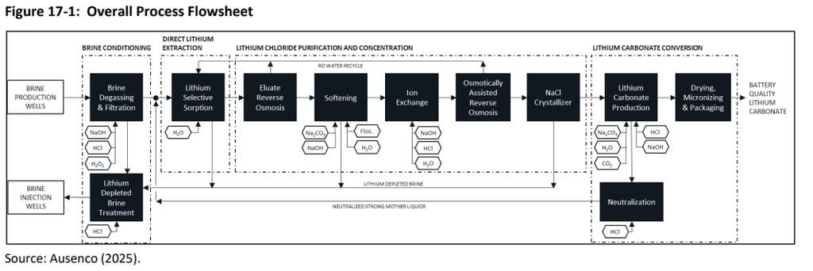

SWA overall process flowsheet, Figure 17-1 from the 2025 DFS.

[Open DFS Figure 17-1 at PDF page 142](https://www.standardlithium.com/_resources/reports/South-West-Arkansas-NI-43-101-DFS.pdf?v=120808%3Fv%3D1761065229#page=142). The visible sequence is brine degassing/filtration → lithium-selective sorption → eluate reverse osmosis → softening → ion exchange → osmotically assisted reverse osmosis → NaCl crystallization → lithium-carbonate production → drying and product handling. The figure also shows reagent additions, water recycle, neutralization and depleted-brine reinjection.

**An official DOE-hosted diagram is also available:** Figure 2.1-2, printed p. 11 / PDF p. 18 of the final EA. It provides a second view of the wells, CPF, reagents and recycle paths. O132.

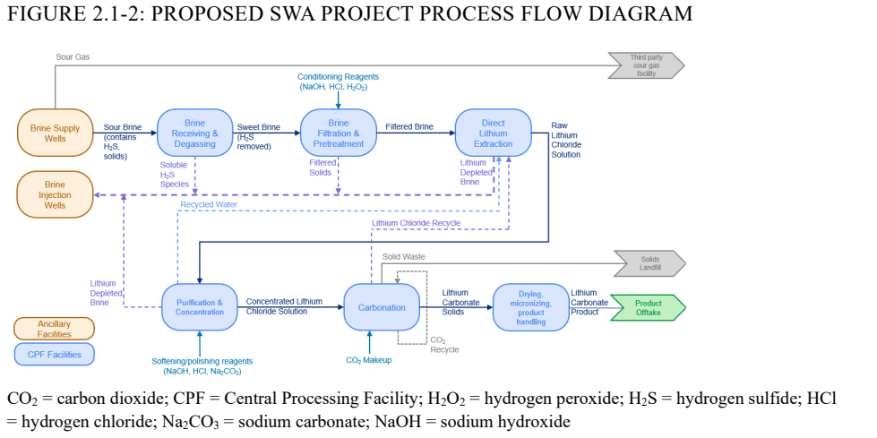

SWA project process flow diagram, Figure 2.1-2 from the May 2026 DOE environmental assessment.

[Open DOE Figure 2.1-2 at PDF page 18](https://www.energy.gov/sites/default/files/2026-05/final-ea-2304-swa-lithium-2026-05.pdf#page=18). A separate well-pad separation flowsheet appears in DFS Figure 17-2, printed p. 122 / PDF p. 144.

These figures cover the major process stages. They do **not** supply a complete numbered-stream material/energy balance with every stream’s flow and composition, or a piping and instrumentation diagram. Use the published **1,325 m³/h commercial design feed** alongside its own design basis, not as the throughput of the earlier pilot samples. O008.

### Pretreatment

Well-pad phase separation → air stripping/scrubbing → cooling → pH/ORP conditioning → multimedia filtration → UF. Gases, oils, precipitated iron and suspended solids; NaOH/H2O2 for conditioning. Figure 17-1 also shows HCl entering the combined pretreatment block, but its precise duty is unresolved. Selected commercial design with supporting trials; no stage-by-stage outlet assay or removal efficiency established here. O561, O562, O563, O564

Compare pretreatment methods across all projects.

## Hell’s Kitchen

The county environmental record covers **Hell’s Kitchen PowerCo 1 (HKP1)** and **LithiumCo 1 (HKL1)**, associated with Controlled Thermal Resources (US) Inc. and named project subsidiaries. Later securities disclosures occur through Plum Acquisition Corp. IV in connection with a proposed combination with Controlled Thermal Resources Holdings Inc. The two entity descriptions and their dates are retained; the proposed transaction is not assumed closed. D004, D041, D043.

The EIR describes geothermal power generation, lithium hydroxide production, supporting utilities, and brine reinjection. The final EIR consists of the draft EIR plus comments, responses and revisions; the downloaded final-EIR volume alone is not a replacement for the full draft report and its appendices. D031, PDF p. 47; O049, O062.

Scroll within the table to see all columns and rows.

| Selected environmental evidence | Reported value | Interpretation |
| --- | --- | --- |
| Net geothermal generation capacity | 49.9 MW | HKP1 generation, not lithium demand. O052 |
| Average lithium-facility demand | Approximately 35 MW | HKL1; peak 40 MW. O053 |
| Annual lithium electricity | 276 million kWh/year | Modelled with 90% availability. O054 |
| Combined operating freshwater | Approximately 6,500 AFY | Includes 200 AFY for HKP1 and 6,300 AFY for HKL1 in the WSA summary. O057 |
| Net combined GHG estimate | −10,435 metric tons CO₂e/year | Includes electricity-generation credit. O063 |
| Hazardous waste | No more than approximately 10 tons/year | A limited waste category; not all residuals. O061 |

The county record contains Planning Commission approval dated December 13, 2023 and Board of Supervisors approval dated January 23, 2024. A later CEC determination describes a March 2025 pretreatment research grant to **Materials Research LLC**; it is not treated as a grant to CTR. O065–O067.

The August 2026 SEC presentation targets Stage 1 lithium capacity of 25,000 TPA LCE and commercial operation in Q4 2030. These are management targets from a later plan, not performance established by the 2023 EIR. Only web text could be checked; the original download remains unavailable. O069, O070.

The EIR’s expected geothermal brine composition includes **250 mg/L lithium**, with magnesium, calcium, boron and other constituents listed in Table 2.0-2. The table does not identify a dated well assay or the exact stream point relative to steam separation and lithium pretreatment. This corrects the initial extraction pass, which overlooked the table. O051, D022, PDF pp. 64–65.

Project-specific recovery and annual reagent-consumption quantities were not established in the screened environmental text. The securities presentation’s operating-cost unit needs clarification before economic comparison. O050, O060, O072.

### Water composition: full published expected table

**A broad expected brine composition is available:** Table 2.0-2 of the EIR, printed pp. 2.0-10–11 / PDF pp. 64–65, lists the 23 entries below. The same table appears in the March 2022 initial study as Table 2, pp. 14–15. This is expected geothermal brine composition, not a dated well assay. D022, D012.

Scroll within the table to see all columns and rows.

| Constituent | Expected concentration (mg/L) | Evidence |
| --- | --- | --- |
| Ammonium (NH4) | 250 | O075 |
| Arsenic (As) | 10 | O076 |
| Barium (Ba) | 250 | O077 |
| Boron (B) | 350 | O078 |
| Bromine (Br) | 100 | O079 |
| Calcium (Ca) | 29,000 | O080 |
| Cesium | 15 | O081 |
| Chloride (Cl) | 156,000 | O082 |
| Cobalt (Co) | <0.05 | O083 |
| Copper (Cu) | 5 | O084 |
| Iodide (I) | 10 | O085 |
| Fluoride (F) | 25 | O086 |
| Iron (Fe) | 1,600 | O087 |
| Lead (Pb) | 100 | O088 |
| Lithium (Li) | 250 | O051 |
| Magnesium (Mg) | 50 | O089 |
| Manganese (Mn) | 1,400 | O090 |
| Potassium (K) | 17,000 | O091 |
| Sodium (Na) | 54,000 | O092 |
| Silica (SiO2) | 350 | O093 |
| Strontium (Sr) | 500 | O094 |
| Sulphate | 5 | O095 |
| Zinc (Zn) | 500 | O096 |

This is the **full published table**, not evidence of a complete analytical characterization. It does not specify a sampling date, laboratory method, pH, density, temperature, TDS total or an unambiguous stream point relative to geothermal flashing and lithium pretreatment. Cesium is printed with the symbol “C” in the source; the element name is retained here without adopting that symbol. Silicon in the SWA table and silica (SiO₂) here have different reporting bases.

Fresh makeup water is separate: the EIR describes IID irrigation-water supply, steam-condensate reuse and filtration/reverse-osmosis treatment. A complete site-specific makeup-water laboratory analysis was not located in the reviewed water-supply sections. D022, printed pp. 2.0-18–19 / PDF pp. 72–73.

### Process diagrams and disclosure limits

**A geothermal brine-handling diagram is present; a complete lithium-extraction flowsheet was not located in the reviewed environmental materials.** The published schematic shows production wells, a high-pressure separator, the steam-to-turbine branch, acid addition, injection pumps and injection wells. It does not draw the lithium extraction, purification or product-conversion stages. O133.

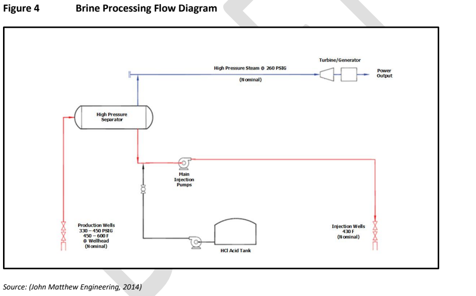

Hell’s Kitchen geothermal brine-processing schematic, Figure 4 in the air-quality appendix.

[Open Figure 4 at PDF page 125 of the combined appendices](https://ceqanet.lci.ca.gov/2022030704/3/Attachment/glQHYR#page=125). Its internal reference is Air Quality Technical Report, p. 8 of 62, dated August 15, 2023; the figure credits John Matthew Engineering (2014). A similar diagram is on [draft-EIR PDF page 64](https://ceqanet.lci.ca.gov/2022030704/3/Attachment/kwHBZD#page=64).

**The lithium process is described in words** in §2.9.2, printed pp. 2.0-17–18 / PDF pp. 71–72: geothermal brine cooling → silica/polymetallic recovery → proprietary LiCl extraction → concentration/purification → conversion to lithium hydroxide monohydrate → crystallization, separation, drying and packaging. This sentence is a summary of the narrative, not a reproduced engineering flowsheet. O134.

That description gives approximately **5.9 million lb/hr** of brine feeding the cooling trains. It is a mass-flow design value for the 2023 plan; no volume conversion or extraction recovery is inferred from it. O135. A numbered-stream balance giving all water, brine, reagent and product compositions was not located in the reviewed environmental documents. The newer SEC presentation’s original remains unavailable for visual diagram review, so this is a bounded finding, not a claim that no other public flowsheet exists. D037.

### Pretreatment

Vacuum-flash cooling → proprietary silica/polymetallic recovery and filtration → lithium extraction. Silica and polymetallic products; boron removal is only a possibility. Recipe and dose not specified. Proposed sequence; proprietary chemistry and impurity residuals unresolved. O568, O569

Compare pretreatment methods across all projects.

## BHER Minerals demonstration

**Disclosure summary:** measured brine lithium **222 ppm**, with 24 parameters in the published brine table; separate canal-water and steam analyses; a process diagram with selected design flows. These are records of a historical demonstration that did not achieve its intended outcome. Collection cutoff: **September 16, 2026**; principal technical source published **August 2024**, describing 2021–2023 work. O144, O201.

BHER Minerals LLC (BHERM), associated with BHE Renewables and CalEnergy, tested a small side stream of Salton Sea geothermal brine at its Region 1 facilities. The final CEC report describes lithium-titanate ion-exchange media, sodium-hydroxide conditioning and hydrochloric-acid elution. The earlier 2020 CEQA exemption named Lilac resin; that initial description must not be assumed to describe every later test. D058, pp. 1–3; D059.

### Published brine, canal-water and steam chemistry

The following reproduces all parameters in **Tables 4–6, printed p. 17 / PDF p. 24**. The report identifies CalEnergy laboratory averages. It dates the canal-water analysis September 13, 2021, but does not give sample dates for the brine and steam averages. Preserve **ppm** as printed: a mass-versus-volume convention and density are not established, so these values are not converted to mg/L.

**Geothermal brine — Table 4.**

Scroll within the table to see all columns and rows.

| Parameter | Reported concentration (ppm) | Evidence |
| --- | --- | --- |
| Arsenic | 15 | O136 |
| Barium | 223 | O137 |
| Cadmium | 1.99 | O138 |
| Calcium | 31365 | O139 |
| Chromium | 0.43 | O140 |
| Copper | 4.15 | O141 |
| Iron | 1001 | O142 |
| Lead | 82.3 | O143 |
| Lithium | 222 | O144 |
| Magnesium | 69.2 | O145 |
| Manganese | 1077 | O146 |
| Nickel | 0.0039 | O147 |
| Potassium | 15599 | O148 |
| Silver | 0.12 | O149 |
| Sodium | 66916 | O150 |
| Strontium | 532 | O151 |
| Zinc | 356 | O152 |
| Chloride | 181019 | O153 |
| Fluoride | 25 | O154 |
| Sulfate | 111 | O155 |
| Silica | 161 | O157 |
| TDS | 305453 | O158 |
| TSS | 418 | O159 |

Scroll within the table to see all columns and rows.

| pH (dimensionless) | Evidence |
| --- | --- |
| 4.82 | O156 |

**Canal water — Table 5, September 13, 2021.** These surprisingly low printed concentrations are retained without speculative unit corrections.

Scroll within the table to see all columns and rows.

| Parameter | Reported concentration (ppm) | Evidence |
| --- | --- | --- |
| Calcium | 0.42 | O160 |
| Chlorides | 1.83 | O161 |
| Iron | 0.01 | O162 |
| Magnesium | 0.12 | O163 |
| Manganese | 0.001 | O164 |
| Potassium | 0.05 | O165 |
| Sodium | 0.47 | O166 |

Scroll within the table to see all columns and rows.

| pH (dimensionless) | Evidence |
| --- | --- |
| 6.96 | O167 |

**Steam — Table 6.** The report calls the stream steam; it does not give a full sampling or condensate-normalization protocol.

Scroll within the table to see all columns and rows.

| Parameter | Reported concentration (ppm) | Evidence |
| --- | --- | --- |
| Barium | 0.035 | O168 |
| Calcium | 68.1 | O169 |
| Iron | 1.04 | O170 |
| Magnesium | 29.4 | O171 |
| Manganese | 0.031 | O172 |
| Potassium | 4.77 | O173 |
| Sodium | 108 | O174 |
| Chloride | 113 | O175 |
| Fluoride | 0.319 | O176 |
| Sulfate | 247 | O177 |
| Antimony | Not detected; limit not given | O178 |
| Arsenic | Not detected; limit not given | O179 |
| Beryllium | Not detected; limit not given | O180 |
| Cadmium | Not detected; limit not given | O181 |
| Cobalt | Not detected; limit not given | O182 |
| Copper | Not detected; limit not given | O183 |
| Lead | Not detected; limit not given | O184 |
| Molybdenum | Not detected; limit not given | O185 |
| Nickel | Not detected; limit not given | O186 |
| Nitrates | Not detected; limit not given | O187 |
| Selenium | Not detected; limit not given | O188 |
| Silver | Not detected; limit not given | O189 |
| Thallium | Not detected; limit not given | O190 |

These are full transcriptions of the selected tables, not proof of exhaustive analytical coverage. Nondetects are not zero. The report does not provide sample-by-sample certificates, detection limits, charge-balance closure or full temperature/density characterization. [Open the original chemistry page](https://www.energy.ca.gov/sites/default/files/2024-08/CEC-500-2024-094.pdf#page=24).

### Process diagram and stream quantities

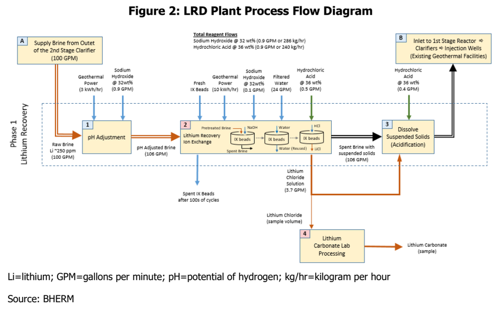

BHER demonstration process diagram, Figure 2, CEC-500-2024-094; design annotations, not achieved operating data.

[Open Figure 2 at PDF page 18](https://www.energy.ca.gov/sites/default/files/2024-08/CEC-500-2024-094.pdf#page=18). The diagram covers brine conditioning, ion exchange, washing and acid elution, spent-brine acidification and return to geothermal facilities. Lithium carbonate conversion is shown only for a **laboratory sample** of the eluate. O200.

Scroll within the table to see all columns and rows.

| Stream or input | Original design quantity | Boundary / issue | Evidence |
| --- | --- | --- | --- |
| Raw brine | 100 gpm; Li approximately 250 ppm | Diagram concentration differs from measured Table 4 average | O191, O192 |
| Incremental freshwater | Approximately 6 gpm (10 acre-ft/year) | Table 1 estimate; existing geothermal facility use excluded | O193 |
| Filtered water | 24 gpm | Figure 2 gross process input; reuse shown | O194 |
| Spent brine | 106 gpm | Return stream, before connection to existing facilities | O195 |
| LiCl solution | 3.7 gpm | Only a sample goes to laboratory product conversion | O196 |
| NaOH at 32 wt% | Total 0.9 gpm / 286 kg/hr | Branches show 0.9 plus 0.1 gpm: unresolved discrepancy | O197 |
| HCl at 36 wt% | Total 0.9 gpm / 240 kg/hr | Acid elution and return-stream acidification | O198 |
| Electricity annotations | 3 and 10 kWh/hr | Two diagram annotations, not a measured energy balance | O199 |

**A completed mass/energy balance is not available in this report.** Table 7 is a sampling-point plan; the mass-balance and techno-economic deliverables were cancelled because of technical difficulties. The 6 gpm net-water estimate and 24 gpm process-water annotation cannot simply be interchanged. O203.

### Test outcome and later development

The final report states that the planned one-tenth commercial-scale demonstration was unsuccessful under field conditions. In the sixth test, adsorption declined from about 80% to 25% over 30 cycles. The supplier termination was acknowledged June 23, 2023. Pretreatment for iron and silicon, media durability and low-pH materials compatibility were key lessons. O201, O202.

The under-$4,000/metric-ton production-cost figure was an objective, not an achieved cost. Full commercial economics, product-purity results, annual emissions, executed offtake and current commercial operating performance are not established here. O204.

BHE and Occidental announced a TerraLithium joint venture in June 2024. Treat that later program separately; this report does not establish its current performance or transfer the failed historical media results to it. O205.

### Pretreatment

Existing secondary clarification → NaOH pH adjustment; weir tank acquired after initial solids clogging. pH conditioning and precipitated solids. Original media-tolerance assumption did not establish adequate iron/silicon removal. Field-test failure informs risk; media degradation was also observed, so no single-cause attribution. O570, O571, O572

Compare pretreatment methods across all projects.

## EnergySource Minerals ATLiS

**Disclosure summary:** a commercial **7,000 gpm brine-processing design**, a published process block diagram, water demand and detailed chemical-use estimates. A complete geothermal-feed or makeup-water composition was **not located in the screened documents**. Collection cutoff: **September 16, 2026**; technical vintages: **2021 EIR and March 2025 DOE EA**. O206, O236.

EnergySource Minerals LLC proposes ATLiS beside Hudson Ranch Power I (HR1) in Imperial County, California. It would process post-geothermal brine after HR1’s secondary clarification and return lithium-depleted brine to HR1 for reinjection. County records use **CUP 20-0008**, **SCH 2020120143**; the later federal review is **DOE/EA-2279**, also circulated under **SCH 2024110237**. This is a separate facility from both Hell’s Kitchen and the BHER demonstration. D060, D074, D085, §2.4.2.

### Water chemistry and flow boundaries

The 2021 EIR and 2025 EA describe impurity removal, ILiAD adsorption/desorption, lithium-chloride purification, conversion through carbonate to hydroxide, crystallization and packaging. Their selected process sections do not disclose a complete named-stream assay. The EIR’s HR1 groundwater-monitoring appendix does contain laboratory analyses, but these describe **environmental monitoring wells**, not geothermal production brine or canal makeup water. They must not be used to fill the missing feed-composition fields. O236.

Scroll within the table to see all columns and rows.

| Quantity | Reported value | Date / basis | Evidence |
| --- | --- | --- | --- |
| Geothermal brine | Approximately 7,000 gpm | 2025 commercial design; impurity-removal inlet | O206 |
| Geothermal brine mass | Approximately 4.0 million lb/hour | 2025 EA safety section; no density reconciliation | O207 |
| Cooling/process water | 3,400 acre-feet/year | IID water supply; design demand | O208 |
| Hourly water requirement | Approximately 90,000 gallons/hour | As separately printed; not exact equivalent of annual figure | O209 |
| Electricity | Up to 17 MW | Purchased power for ATLiS operations | O210 |
| Fe-silica cake | 136,200 metric tonnes/year dry; about 190,000 tonnes/year wet | Design residue quantities; dry/wet bases differ | O211, O212 |

The source pairs 90,000 gallons/hour with 3,400 acre-feet/year; those do not match under continuous annual operation. No operating-hour correction is imposed. Brine flow, freshwater purchase, pond storage and reinjection are separate quantities. Full lithium concentration, recovery, product assay, eluate chemistry and a closed water balance remain gaps in this reviewed environmental package. O209, O236.

### Published process diagram

[figure not shown]

ATLiS NEPA process flow diagram, Figure 4 of the March 2025 DOE EA; source EnergySource Minerals.

[Open Figure 4 at PDF page 15](https://www.energy.gov/sites/default/files/2025-03/final-ea-fonsi-ea-2279-atlis-2025-03.pdf#page=15). The diagram shows the main processing stages, two filter-cake outlets and the return-brine connection. It does not expose the proprietary ILiAD equipment arrangement, regeneration steps or numerical compositions/flows of each internal stream. O213.

### Chemical inputs, residues and emissions

The full chemical-use table below preserves the source units. Despite the source title “Annual Chemical/Materials Usage,” several rows are daily rates. Chemical ton conventions and solution strengths are not established by this table. These are design inputs, not measured consumption or water composition. D061, p. 34 / PDF p. 40, Table 13.

Scroll within the table to see all columns and rows.

| Chemical/material | Reported quantity | Original unit | Evidence |
| --- | --- | --- | --- |
| Limestone | 102.0 | tons/day | O217 |
| Quicklime | 158.0 | tons/day | O218 |
| Flocculant | 2256.0 | pounds/day | O219 |
| HCl | 208.4 | tons/day | O220 |
| Antifoam | 906.0 | pounds/day | O221 |
| Sodium hydroxide | 1356.1 | tons/year | O222 |
| Soda ash | 40589.5 | tons/year | O223 |
| EDTA | 0.8 | tons/year | O224 |
| Lithium coagulant | 549.0 | pounds/day | O225 |
| Canal coagulant | 10.0 | pounds/day | O226 |
| Sodium bisulfite | 2.8 | tons/year | O227 |
| Lithium biocide | 6.0 | pounds/day | O228 |
| Sodium hypochlorite | 0.2 | tons/day | O229 |
| Canal anti-scalant | 5000.0 | pounds/year | O230 |
| Lithium polymer | 25.00 | pounds/day | O231 |
| Actiflo polymer | 14.0 | pounds/day | O232 |
| Veolia lime | 19079.4 | tons/year | O233 |
| Cooling tower chemical | 8.5 | tons/year | O234 |
| CO2 | 1008.0 | tons/year | O235 |

The EA estimates filter cake disposal to Wellton, Arizona until commercial uses become viable. It incorporates a **16,650.91 metric tonnes/year** construction-plus-operation GHG estimate from the 2021 EIR; construction is annualized over 30 years. Its separate avoided-gasoline calculation is not a measured lithium-product carbon footprint. O212, O215.

### Approval, schedule and remaining gaps

DOE announced its final EA and signed FONSI on **March 26, 2025**, explicitly stating that this was not a final decision to issue a federal loan. The EA expects full production in **Q4 2027**; the 2021 EIR had expected operations in Q2 2023. These are dated plans, not independently verified construction milestones. O237, O214; D085, p. 2.0-10 / PDF p. 54.

Capacity also needs a product basis: the 2021 EIR estimates shipments of 19,000 metric tons of “Li product,” while the later EA uses 20,000 tons/year in an avoided-emissions calculation. Neither wording should silently become a consistent LCE capacity. O216; D085, PDF p. 54. Project cost, executed offtake terms, complete financing, current construction status and actual commercial performance are not established by this package.

### Pretreatment

HR1 post-secondary-clarifier brine → Fe/silica removal → Mn/Zn removal → ILiAD. Separated solids → filter-press dewatering. HCl pH control disclosed; limestone/CaO facilities listed. Detailed chemical sequence not disclosed. Commercial proposal; Fe/silica cake initially a waste, Mn/Zn intended products. No verified operating efficiency. O573, O574; O211.

Compare pretreatment methods across all projects.

## Ogden / Great Salt Lake

**Disclosure summary:** selected multi-cation lake and pond tables, a historical East/West process flowsheet, and design water, energy and reagent quantities. **Evaporation precedes DLE**; ambient lake water is not the same stream as concentrated DLE feed. Collection cutoff: **September 16, 2026**. Chemistry and process design: Compass **2022 technical report**; latest relevant proposal screened: EnergyX **July 2026 SEC circular**. D073, D089.

Compass Minerals’ Ogden operation processes Great Salt Lake salts. Its 2022 lithium initial assessment used EnergySource Minerals’ ILiAD technology and separate East and West product plants. The issuer-hosted PDF is preserved as **D073**, a supplement to the SEC technical exhibit **D064**, whose original download was blocked. D073, §14.

### Lake and pond composition

The following is the **full five-cation Table 7.2**, including its published aggregate. Sampling covered 2020 and the first half of 2021. FB-2 is in the south arm; LVG-4 and RD-2 are north-arm locations. Location/depth averages must not be merged into an invented representative plant feed. All concentrations are **mg/L**. D073, pp. 44–45 / PDF pp. 56–57.

Scroll within the table to see all columns and rows.

| Location / depth | Samples | B (mg/L) | Ca (mg/L) | K (mg/L) | Li (mg/L) | Mg (mg/L) | Evidence |
| --- | --- | --- | --- | --- | --- | --- | --- |
| FB-2 Deep | 6 | 34.9 | 314 | 4642 | 37.8 | 7293 | O241 |
| FB-2 Deep Intermediate | 6 | 28 | 306 | 3908 | 30.7 | 6102 | O246 |
| FB-2 Deep Shallow | 6 | 24.5 | 282 | 3162 | 25.9 | 5002 | O251 |
| FB-2 Shallow | 5 | 23.8 | 280 | 3380 | 27.2 | 5274 | O256 |
| FB-2 Shallow Intermediate | 6 | 25 | 275 | 3442 | 27.6 | 5347 | O261 |
| LVG-4 Deep | 6 | 45.9 | 398 | 7870 | 58.6 | 11877 | O266 |
| LVG-4 Intermediate | 6 | 46.2 | 355 | 7475 | 56.8 | 11448 | O271 |
| LVG-4 Shallow | 6 | 45.8 | 348 | 7545 | 57 | 11550 | O276 |
| LVG-4 Surface | 4 | 42.8 | 342 | 7058 | 52.6 | 10595 | O281 |
| RD-2 Deep | 6 | 47.7 | 349 | 7305 | 55.2 | 11073 | O286 |
| RD-2 Intermediate | 6 | 46.6 | 371 | 7463 | 56.8 | 11332 | O291 |
| RD-2 Shallow | 6 | 48.5 | 401 | 7665 | 57.4 | 11545 | O296 |
| RD-2 Surface | 1 | 48.4 | 266 | 7380 | 51.6 | 9920 | O301 |
| Sub Total | 70 | 38.5 | 335 | 5934 | 45.4 | 9058 | O306 |

Each constituent has its own observation in the evidence appendix. The source aggregate is not an additional independent sample. The narrative spells LVG-4 as LGV-4; table labels above are retained.

**Pond 114 interstitial brine — full Table 7.3.** All samples are dated **March 3, 2020**. Concentrations are mg/L; halite thickness is feet. Ratios are reported source values, not new calculations.

Scroll within the table to see all columns and rows.

| Sample | Halite (ft) | Li (mg/L) | K (mg/L) | Mg (mg/L) | Na (mg/L) | K:Li (ratio) | Mg:Li (ratio) | Evidence |
| --- | --- | --- | --- | --- | --- | --- | --- | --- |
| 114TP01 | 8.0 | 238 | 18400 | 41400 | 63300 | 77:1 | 174:1 | O308 |
| 114TP02 | 6.5 | 328 | 26700 | 50100 | 51800 | 81:1 | 153:1 | O314 |
| 114TP03 | 6.5 | 321 | 25300 | 50900 | 52600 | 79:1 | 159:1 | O320 |
| 114TP04 | 6.5 | 279 | 23800 | 46100 | 52400 | 85:1 | 165:1 | O326 |
| 114TP05 | 5.5 | 265 | 23100 | 43000 | 46700 | 87:1 | 162:1 | O332 |
| 114TP06 | 6.5 | 125 | 12900 | 23400 | 89000 | 103:1 | 187:1 | O338 |
| 114TP07 | 6.5 | 208 | 17400 | 38400 | 68000 | 84:1 | 185:1 | O344 |
| Average | — | 252 | 21100 | 41900 | 60500 | 84:1 | 166:1 | O350 |

[Open Table 7.3 at PDF page 60](https://s22.q4cdn.com/834578860/files/doc_downloads/2022/09/CMP-Ex96.1-Revised-Ogden-Lithium-Technical-Report-Summary.pdf#page=60). These samples show lateral variability; the source assumes a full-thickness mix and does not resolve vertical chemistry. Other pond tables remain accessible in **Tables 7.5–7.9, PDF pp. 66–68**; they were identified but not fully transcribed in this pass. The selected tables above lack a complete anion suite, pH, density, TDS and a linked production-stream assay. Laboratory field-blank tables in §8 are quality-control evidence, not the brine composition.

The narrative separately gives **51 mg/L** for ambient north-arm brine, **180 mg/L** for an average one-year concentrated brine, and **>1,000 mg/L** for final magnesium-chloride bittern. These are different streams and averaging bases. The 2022 design considers interstitial brine, approximately two-year brine and highly concentrated DustGard brine. O356, O357, O358; D073, §14.2.

### Historical process flowsheet and demands

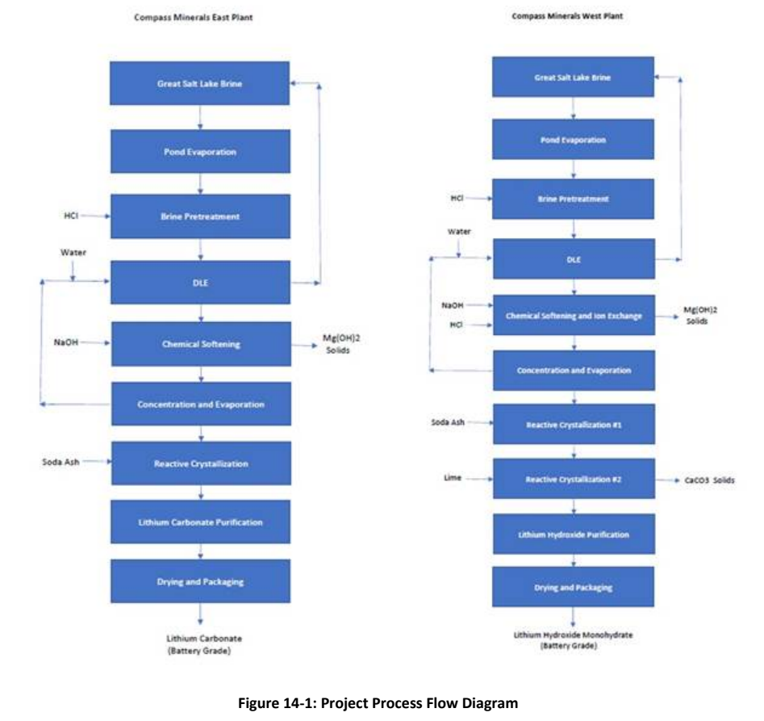

Ogden East and West process block flowsheets, Figure 14-1 of the 2022 Compass Minerals technical report.

[Open Figure 14-1 at PDF page 148](https://s22.q4cdn.com/834578860/files/doc_downloads/2022/09/CMP-Ex96.1-Revised-Ogden-Lithium-Technical-Report-Summary.pdf#page=148). Both branches include pond evaporation, pretreatment and DLE. East produces lithium carbonate; West adds conversion to lithium hydroxide monohydrate. Reagents and water-recycle branches are shown. This is a **historical block flowsheet**, with no complete numbered-stream material/energy balance, and is not a published EnergyX 2026 engineering design. O359.

Scroll within the table to see all columns and rows.

| 2022 design quantity | East plant | West plant | Interpretation |
| --- | --- | --- | --- |
| Fresh water from site wells | 487 AFY O360 | 693 AFY O361 | Design consumption; AFY defined by source footnote |
| Connected electrical load | 2,901 kW O367 | 5,848 kW O369 | Pond pumps separately 5,000 kW O371 |
| Annual electrical energy | 21,601 MWh/year O368 | 43,544 MWh/year O370 | Pond pumps separately 31,050 MWh/year O372 |
| Intended output | 10,800 tonnes/year Li2CO3 O364 | 27,800 tonnes/year LHM O365 | 85% equipment-effectiveness assumption; different products |
| Capital estimate | US$262.0 million O362 | US$710.1 million O363 | Historical FEL-1 estimate; exclusions and cost-year caveat below |

The report describes pilot/column/cycle results exceeding **85% lithium recovery** across tested feeds. This does not establish full commercial brine-to-product performance. O366.

Capital values include contingency but exclude items such as sustaining capital, land acquisition, sunk costs, working capital and financing. The report’s general currency convention is constant Q3 2021 USD, while its operating-cost basis specifically uses Q1 2022 USD; Table 18.5 does not independently restate the capital cost year. This ambiguity is retained, and the figures are not promoted to current project costs. D073, §§2.2, 18.1.1, 18.2.1.

Reagent utilization is also disclosed for the historical design: East caustic 24, HCl 2, soda ash 58 and clarifier polymer 2 tonnes/day; West caustic 43.3, HCl 5.5, soda ash 107.5, quicklime 73.9, CO2 3.3 and clarifier polymer 3.1 tonnes/day. Each quantity is retained in the evidence appendix. D073, Tables 18.1–18.2 / PDF p. 178.

### Keep the 2022 design and 2026 proposal separate

Compass’s 2025 annual filing reports that it terminated its lithium-development pursuit on **January 23, 2024**, following the 2023 investment pause. O383.

EnergyX’s July 2026 filing describes a **March 19, 2026 largely non-binding MOU**, with proposed Phase I and Phase II targets of approximately 10,000 and 20,000 tpa LCE. Definitive agreements and approvals remain conditions. The July circular specified a 180-day expiry after the March 19 execution; an extension or executed definitive agreement was not established by this collection cutoff. O384. The separate 2026 proposal does not inherit the old recovery, water, cost or flowsheet claims.

The latest Compass June-quarter filing was inventoried and web-screened without a lithium-specific update. The blocked SEC originals, full current engineering design, current stream assays, project funding, executed offtake and a completed water balance remain gaps. D090.

### Pretreatment

Evaporation ponds and prior salt recovery → brine filtration / pretreatment with a disclosed HCl input → ILiAD. Figure 14-1 shows HCl entering pretreatment in both plants; its purpose, dose, pH and order relative to filtration are unspecified. Total HCl consumption also includes downstream uses. Different concentrated feed streams; specific filter type and outlet specifications are not given in the reviewed process section. Historical Compass design; not the later EnergyX configuration. No assumed raw-brine Mg-softening step. O575, O576

Compare pretreatment methods across all projects.

## Anson / Blackstone Green River

**Disclosure summary:** an **18-parameter brine table** in a November 2023 draft injection-permit attachment, including lithium **170–210 ppm**, density and pH. The table’s stream label is ambiguous. An injection schematic is available, but a complete lithium-process flowsheet was not located in the reviewed package. Collection cutoff: **September 16, 2026**. O385, O404.

Anson’s August 2024 announcement links its wholly owned Blackstone subsidiary and the Utah injection approval to **Green River**. The agency’s current index lists Blackstone under **UTU-19-F4-8F9143D**. Anson’s separately named Paradox project is not merged with this site. O405, O406.

### Full published permit chemistry table

**Read this qualification first:** Table D-1 calls the stream “production brine”; the preceding page calls it spent brine after lithium/bromide depletion and rinse-water dilution. No dated assay or lab method resolves the conflict. The ranges below are transcribed as proposed permit chemistry, **not verified raw-feed or operating-effluent measurements**. Ppm is retained without converting to mg/L. D079, pp. 16–17.

Scroll within the table to see all columns and rows.

| Parameter | Published range (ppm) | Evidence |
| --- | --- | --- |
| Lithium | 170–210 | O385 |
| Bromine | 3500–4000 | O386 |
| Boron | 1400–1700 | O387 |
| Sodium | 18000–20000 | O388 |
| Potassium | 25000–29000 | O389 |
| Calcium | 45000–50000 | O390 |
| Magnesium | 35000–40000 | O391 |
| Chloride | 220000–260000 | O392 |
| Iron | 200–250 | O393 |
| Sulfate | 50–100 | O394 |
| Strontium | 1500–1800 | O395 |
| Barium | 1–4 | O396 |
| Zinc | 3–4 | O397 |
| Bicarbonate | 1200–1400 | O398 |
| Fluoride | 30–35 | O399 |
| TDS | 350000–400000 | O400 |

Scroll within the table to see all columns and rows.

| Density (g/cm³) | pH (dimensionless) | Evidence |
| --- | --- | --- |
| 1.27–1.28 | 4.5–5.0 | O401, O402 |

**Cross-project reuse:** all ranges also occur in Paradox’s 2024 draft. Their common sample/design provenance is unresolved, so they are not counted as independent assays.

[Open Table D-1 at PDF page 17](https://www.utah.gov/pmn/files/1044667.pdf#page=17). These are all listed parameters, including density and pH. Temperature, analytical methods, detection limits, sample dates and a complete charge-balanced analysis are not supplied. Separate raw-feed, eluate, spent-brine and fresh-water analyses would be needed to resolve the process balance.

### Injection flow and diagram limits

The draft attachment sets an injection-flow ceiling of **2,000 gpm**, with automatic shutdown near the maximum. This is a **draft permit limit**, not achieved DLE throughput or a current validated final-permit condition. O403.

[Figure F-1, PDF page 26](https://www.utah.gov/pmn/files/1044667.pdf#page=26) shows an **injection pump manifold**. Its following component table credits an ASARCO 1993 copper-mining report. The drawing is therefore not reproduced as if it were a project-specific lithium flowsheet. It does not disclose extraction, regeneration, purification, product conversion or a full material balance. O404.

### Permit status and remaining evidence

The current agency index provides final permit and statement-of-basis links, but both returned HTML viewer/login responses to collection instead of the expected PDFs. They are recorded as unavailable originals. The November 2023 public-notice permit, fact sheet and attachments remain distinct historical drafts. O406; D069, D070, D078, D092.

An injection authorization listing does not demonstrate that every construction/operating approval is in place or that the plant is producing. Current recovery, product purity, reagent consumption, energy demand, freshwater consumption, emissions, costs, financing, offtake and commercial commissioning are not established by this selected permit package. Those gaps remain visible rather than being filled with figures from Anson’s separate Paradox project.

### Pretreatment

No upstream DLE pretreatment train established in reviewed injection package. Injection-side solids handling is not evidence of the incoming DLE treatment. Permit chemistry has a production/spent-brine label conflict; no method inferred from it. D079, Attachment D pp. 16–17; O404.

Compare pretreatment methods across all projects.

## Waterleaf / Lilac Great Salt Lake Phase 1

**Disclosure summary:** measured pilot raw-brine/eluate chemistry; a separate groundwater laboratory panel; and public commercial-design chemistry, flows, density and solids for 12 numbered streams. Figure 33 links the outfall/waste streams. Full Appendix D.4 is redacted; its public Table 23 excerpt is available. **Cutoff: September 16, 2026.**

Waterleaf Phase 1 LLC proposes Lilac ion-exchange DLE on Gunnison Bay, the north arm of Great Salt Lake, in Box Elder County, Utah. This is separate from Compass/EnergyX Ogden and US Magnesium. The agency draft identifies commercial UPDES **UT0026352**, replacing demonstration permit **UT0026280**. The June 30, 2026 fact sheet and July public notice are drafts, not evidence of final authorization or completed construction. D111, D112; D116, PDF p. 22.

### Pilot brine and eluate composition

Table 11 covers selected stable periods in optimal pilot weeks 16–28, excluding ramp-up and transitions. It is a measured pilot average, not the whole commercial design feed. All six listed constituents are reproduced; anions, TDS and charge balance are absent from this table. D113, pp. 83–84.

Scroll within the table to see all columns and rows.

| Constituent | Raw brine (mg/L) | DLE eluate (mg/L) | Evidence |
| --- | --- | --- | --- |
| Lithium | 69 | 2044 | O407, O408 |
| Sodium | 85774 | 603 | O409, O410 |
| Magnesium | 13290 | 293 | O411, O412 |
| Calcium | 300 | 97 | O413, O414 |
| Potassium | 8362 | 203 | O415, O416 |
| Boron | 50 | 0.9 | O417, O418 |

Reported pilot DLE recovery is **87%** (O419). Commercial whole-process recovery is **78.8%**, combining 84.5% DLE and 93.3% downstream recovery (O421). Commercial design is **5,000 mt/yr lithium carbonate** at 90% nominal availability. The rounded **11,300 gpm** intake is the equipment-design case; Table 23 separately gives nominal intake **33,347 L/min** and design intake **42,610 L/min**. Keep those bases separate when calculating an intensity. These are design assumptions, not achieved commercial output. O420, O422, O587, O599.

Pilot crystallization occurred in batches at Lilac’s Oakland laboratory; the commercial design puts it on site and recovers water differently. Pilot potable water came from Geneva Rock, while commercial makeup is proposed from groundwater. Those boundaries prevent treating pilot and commercial effluents as interchangeable. D113, p. 84.

### Commercial design stream chemistry

**Table 23 is public.** It reports eleven aqueous-ion rows for twelve numbered streams, with nominal/design flows, density and solids. These are **rounded commercial model values**, separate from the measured pilot Table 11. The source identifies the composition block as nominal. D113, [Table 23, PDF pp. 130–131](https://ffsl.utah.gov/wp-content/uploads/Waterleaf_GSL_P1_Operations-Application_Redacted.pdf#page=130).

Stream **3101 is raw brine** and **3501 is total depleted-brine outfall**. The source’s stream names are reproduced below; MMF means multimedia filtration and RO means reverse osmosis. The numbered diagram and flow tables link these compositions to process location.

Scroll within the table to see all columns and rows.

| Stream | Source description |
| --- | --- |
| 3101 | Raw Brine |
| 3501 | Total Depl. Brine Outfall |
| 4103 | Raw Brine MMF Backwash |
| 4601 | Depl. Brine |
| 4603 | Fresh NaOH for Brine Neut. |
| 4607 | Dilute Flocc. |
| 4609 | Depl. Brine MMF Feed |
| 4611 | Depl. Brine |
| 4624 | 12% NaClO |
| 4625 | Depl. Brine MMF Filtrate |
| 4626 | 15% Na2SO3 Depl. Brine MMF Filtrate |
| 4704 | Water Recovery RO Retentate |

The long stream 4626 header is retained as printed; Figure 33 identifies its reagent as **Na₂SO₃ (sodium sulfite)**. Source dashes mean **not reported in this table**, not zero or a detection limit. The printed ionic labels below are source notation, not independently verified speciation.

#### Major cations

Scroll within the table to see all columns and rows.

| Stream | Li+ (mg/L) | Na+ (mg/L) | Mg2+ (mg/L) | Ca2+ (mg/L) | K+ (mg/L) |
| --- | --- | --- | --- | --- | --- |
| 3101 | 68.0 O683 | 98,464 O695 | 14,633 O707 | 309 O719 | 8,721 O731 |
| 3501 | 14.2 O684 | 97,872 O696 | 14,482 O708 | 300 O720 | 8,638 O732 |
| 4103 | 77.4 O685 | 98,327 O697 | 14,576 O709 | 307 O721 | 8,691 O733 |
| 4601 | 12.1 O686 | 98,190 O698 | 14,539 O710 | 300 O722 | 8,672 O734 |
| 4603 | 0.0 O687 | 140,135 O699 | 3.8 O711 | 1.1 O723 | 2.3 O735 |
| 4607 | 0.0 O688 | 34.5 O700 | 3.9 O712 | 1.2 O724 | 2.4 O736 |
| 4609 | 12.0 O689 | 97,842 O701 | 14,479 O713 | 300 O725 | 8,637 O737 |
| 4611 | 12.0 O690 | 97,700 O702 | 14,455 O714 | 300 O726 | 8,623 O738 |
| 4624 | - O691 | 42,805 O703 | - O715 | - O727 | - O739 |
| 4625 | 12.0 O692 | 97,844 O704 | 14,479 O716 | 300 O728 | 8,637 O740 |
| 4626 | 0.0 O693 | 64,299 O705 | 3.8 O717 | 1.1 O729 | 2.4 O741 |
| 4704 | 11.0 O694 | 17,548 O706 | 2,219 O718 | 374 O730 | 1,350 O742 |

#### Other constituents and anions

Scroll within the table to see all columns and rows.

| Stream | B3+ (mg/L) | Sr2+ (mg/L) | Fe2+ (mg/L) | Mn2+/Mn4+ (mg/L) | Cl− (mg/L) | SO4²− (mg/L) |
| --- | --- | --- | --- | --- | --- | --- |
| 3101 | 62.0 O743 | 4.0 O755 | 0.6 O767 | 0.0 O779 | 183,942 O791 | 26,976 O803 |
| 3501 | 61.4 O744 | 3.4 O756 | 0.6 O768 | 0.0 O780 | 182,249 O792 | 27,240 O804 |
| 4103 | 61.8 O745 | 4.0 O757 | 0.6 O769 | 0.0 O781 | 183,226 O793 | 27,331 O805 |
| 4601 | 61.6 O746 | 3.4 O758 | 0.6 O770 | 0.2 O782 | 182,943 O794 | 27,317 O806 |
| 4603 | 0.0 O747 | 0.0 O759 | 0.0 O771 | 0.0 O783 | 92.8 O795 | 82.8 O807 |
| 4607 | 0.0 O748 | 0.0 O760 | 0.0 O772 | 0.0 O784 | 62.0 O796 | 7.5 O808 |
| 4609 | 61.4 O749 | 3.4 O761 | 0.6 O773 | 0.0 O785 | 182,207 O797 | 27,205 O809 |
| 4611 | 61.3 O750 | 3.4 O762 | 0.6 O774 | 0.0 O786 | 181,926 O798 | 27,193 O810 |
| 4624 | - O751 | - O763 | - O775 | - O787 | 4,280.1 O799 | - O811 |
| 4625 | 61.4 O752 | 3.4 O764 | 0.6 O776 | 0.0 O788 | 182,210 O800 | 27,206 O812 |
| 4626 | 0.0 O753 | 0.0 O765 | 1.8 O777 | 0.0 O789 | 96.6 O801 | 1,039 O813 |
| 4704 | 8.8 O754 | 0.6 O766 | 0.1 O778 | 0.3 O790 | 32,024 O802 | 4,234 O814 |

This reproduces all listed chemistry cells, including dashes. It is not an exhaustive chemical characterization or a measured operating balance. The underlying full Appendix D.4 remains redacted. Do not substitute design raw-brine **68.0 mg/L Li** for the **69 mg/L pilot average**, or treat design outfall **14.2 mg/L Li** as a lithium-rich product stream.

### Groundwater: full listed sample results

Appendix E.2 contains an ACZ laboratory package for **sample L94016-01, well 13-4110, collected April 11, 2025 at 08:45**. This tested an existing well to investigate the aquifer for a potential new supply well roughly five miles away. It is **not lake brine or a confirmed final production-well assay**. The following tables reproduce all environmental-sample result entries on lab pages 2, 3, 12 and 17, including calculated parameters; preparation records, surrogate recovery, QC spikes and the trip blank remain in the linked original. **Lithium is not listed in this groundwater panel.** O511.

Dissolved metals were laboratory filtered at 0.45 µm. **MDL** is the method detection limit; **PQL** is the practical quantitation limit. **U** means not detected above the stated limit; **B** marks an estimated result between MDL and PQL. A nondetect is not zero.

Scroll within the table to see all columns and rows.

| Dissolved constituent | Result (mg/L) | MDL (mg/L) | PQL (mg/L) | Qualifier | Method | Evidence |
| --- | --- | --- | --- | --- | --- | --- |
| Aluminum | <0.14 | 0.14 | 0.5 | U | EPA 200.7 | O464 |
| Arsenic | 0.00133 | 0.0002 | 0.001 | — | EPA 200.8 | O465 |
| Barium | 0.0573 | 0.009 | 0.035 | — | EPA 200.7 | O466 |
| Boron | 0.295 | 0.03 | 0.1 | — | EPA 200.7 | O467 |
| Cadmium | <0.00005 | 0.00005 | 0.00025 | U | EPA 200.8 | O468 |
| Calcium | 82.9 | 0.1 | 0.5 | — | EPA 200.7 | O469 |
| Chromium | 0.00108 | 0.0005 | 0.002 | B | EPA 200.8 | O470 |
| Copper | 0.00812 | 0.0016 | 0.004 | — | EPA 200.8 | O471 |
| Iron | <0.06 | 0.06 | 0.15 | U | EPA 200.7 | O472 |
| Lead | <0.0001 | 0.0001 | 0.0005 | U | EPA 200.8 | O473 |
| Magnesium | 35.2 | 0.2 | 1 | — | EPA 200.7 | O474 |
| Manganese | 0.065 | 0.01 | 0.05 | — | EPA 200.7 | O475 |
| Mercury | <0.0002 | 0.0002 | 0.001 | U | EPA 245.1 | O476 |
| Molybdenum | 0.00240 | 0.0002 | 0.0005 | — | EPA 200.8 | O477 |
| Nickel | <0.008 | 0.008 | 0.04 | U | EPA 200.7 | O478 |
| Potassium | 27.6 | 0.5 | 1 | — | EPA 200.7 | O479 |
| Selenium | 0.00244 | 0.0001 | 0.00025 | — | EPA 200.8 | O480 |
| Silver | <0.0001 | 0.0001 | 0.0005 | U | EPA 200.8 | O481 |
| Sodium | 884 | 0.2 | 1 | — | EPA 200.7 | O482 |
| Uranium | 0.00274 | 0.0001 | 0.0005 | — | EPA 200.8 | O483 |
| Zinc | 0.119 | 0.02 | 0.05 | — | EPA 200.7 | O484 |

Scroll within the table to see all columns and rows.

| Wet-chemistry parameter | Result (mg/L) | MDL (mg/L) | PQL (mg/L) | Qualifier | Evidence |
| --- | --- | --- | --- | --- | --- |
| Bicarbonate as CaCO3 | 174 | 2 | 20 | — | O485 |
| Carbonate as CaCO3 | 7.1 | 2 | 20 | B | O486 |
| Hydroxide as CaCO3 | <2 | 2 | 20 | U | O487 |
| Total alkalinity as CaCO3 | 181 | 2 | 20 | — | O488 |
| Chloride | 1700 | 100 | 200 | — | O489 |
| Fluoride | 0.70 | 0.15 | 0.35 | — | O490 |
| Dissolved hardness as CaCO3 | 352 | 0.2 | 5 | — | O491 |
| Nitrate as N | 1.31 | 0.02 | 0.1 | — | O492 |
| Nitrate/nitrite as N | 1.31 | 0.02 | 0.1 | RA; ZU | O493 |
| Nitrite as N | <0.01 | 0.01 | 0.05 | U; RA; ZU | O494 |
| Ammonia nitrogen | <0.1 | 0.1 | 0.2 | U; RA | O495 |
| Filterable residue (TDS), 180°C | 2890 | 20 | 40 | — | O496 |
| Sulfate | 105 | 5 | 25 | M3 | O497 |

Extended qualifiers: **RA** means a duplicate difference was not used because concentration was too low; **ZU** records analysis/filter-workgroup timing; **M3** means the spike recovery was unusable because of the sample/spike concentration ratio, while the control sample was acceptable. The lab pH has **H**, indicating exceeded holding time. D113, PDF pp. 813, 820.

Scroll within the table to see all columns and rows.

| Other parameter | Result | Unit | Qualification | Evidence |
| --- | --- | --- | --- | --- |
| Cation–anion balance | -6.9 | % | Calculated, source sign retained. | O498 |
| Sum of anions | 54 | meq/L | Calculated. | O499 |
| Sum of cations | 47 | meq/L | Calculated. | O500 |
| Laboratory pH | 8.2 | pH units | H: method hold time exceeded; pH is an immediate field test. This is not field pH. | O501 |
| Temperature at laboratory pH measurement | 21.6 | °C | Not reservoir or field temperature. | O502 |
| Sodium adsorption ratio | 21 | dimensionless | USGS I1738-78. | O503 |

Scroll within the table to see all columns and rows.

| Organic constituent | Result (µg/L) | MDL (µg/L) | PQL (µg/L) | Qualifier | Evidence |
| --- | --- | --- | --- | --- | --- |
| Benzene | <1 | 1 | 5 | U; Q9 | O504 |
| Ethylbenzene | <1 | 1 | 5 | U; Q9 | O505 |
| m,p-Xylene | <2 | 2 | 10 | U; Q9 | O506 |
| o-Xylene | <1 | 1 | 5 | U; Q9 | O507 |
| Toluene | <1 | 1 | 5 | U; Q9 | O508 |

All five organic results carry **Q9**: insufficient sample to meet method QC requirements. D113, PDF p. 825.

Scroll within the table to see all columns and rows.

| Radiochemistry | Printed result (pCi/L) | Error ± (pCi/L) | LLD (pCi/L) | Evidence |
| --- | --- | --- | --- | --- |
| Gross alpha | 18 | 20 | 51 | O509 |
| Gross beta | 21 | 15 | 40 | O510 |

Both radiochemistry results are below their reported lower limits of detection (LLD); they are not quantified detections. Gross alpha also carries the lab’s RG precision qualifier. This is a broad published analytical panel, not proof that every dissolved species has been characterized. D113, PDF pp. 826, 829.

### Public flowsheet and commercial water balance

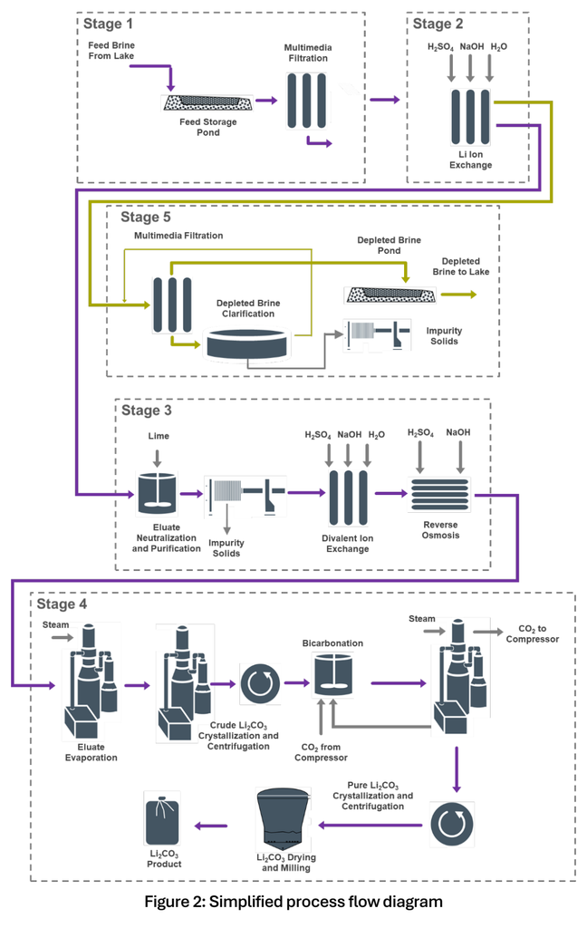

Waterleaf simplified commercial process flow diagram, Figure 2 of the operations application.

O423. [Open Figure 2 at PDF page 39](https://ffsl.utah.gov/wp-content/uploads/Waterleaf_GSL_P1_Operations-Application_Redacted.pdf#page=39). The diagram connects intake filtration, lithium ion exchange, eluate purification/concentration, carbonate crystallization and depleted-brine return. The later DWQ fact sheet describes off-site further processing and lists three main stages, while its attachment depicts carbonate production. The application and discharge-permit boundaries need reconciliation. D112, pp. 1–2 and 19.

#### Numbered outfall and waste flowsheet

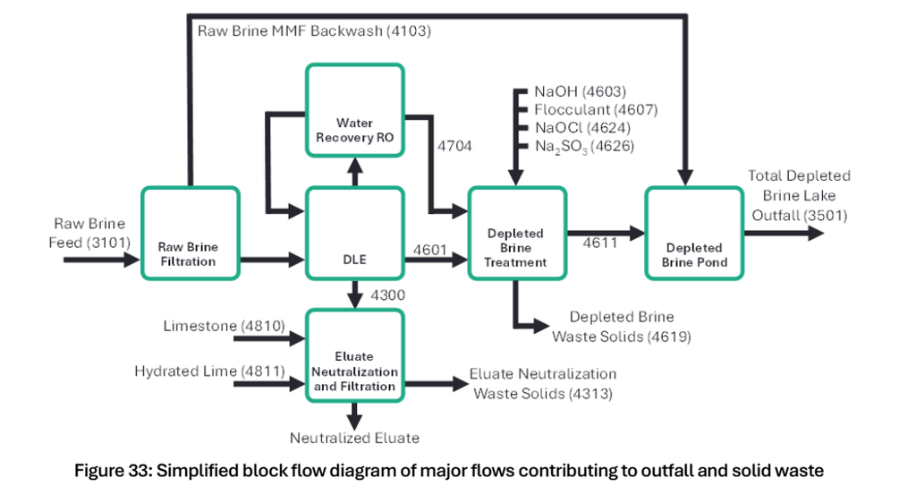

Waterleaf Figure 33: numbered streams contributing to outfall and solid waste. Source diagram, commercial design.

O815. [Open Figure 33 at PDF page 128](https://ffsl.utah.gov/wp-content/uploads/Waterleaf_GSL_P1_Operations-Application_Redacted.pdf#page=128). Raw-brine backwash, depleted-brine treatment, RO retentate and reagent additions feed the outfall branch. Eluate neutralization and its solids are separate. The diagram maps to Table 23 chemistry; it does not cover the complete carbonate-conversion balance.

#### Table 23: nominal and design stream flows

All twelve source columns are retained. **Nominal** is the 90%-uptime case without margin; **Design** is the 100%-uptime equipment case with 15% margin. These rounded total-stream flows differ from Table 12’s water-content masses. The two volumetric units and mass unit are preserved as printed, without forcing their rounded values or densities to agree exactly. D113, PDF p. 130; operating bases on p. 89.

Scroll within the table to see all columns and rows.

| Stream / source description | Nominal flow (L/min) | Design flow (L/min) | Density (kg/L) | Solids (w%) |
| --- | --- | --- | --- | --- |
| 3101 · Raw brine | 33,347 O587 | 42,610 O599 | 1.2 O659 | 0.007 O671 |
| 3501 · Total outfall | 33,666 O588 | 43,017 O600 | 1.2 O660 | 0.006 O672 |
| 4103 · Raw-brine MMF backwash | 1,129 O589 | 1,443 O601 | 1.2 O661 | 0.2 O673 |
| 4601 · Depleted brine | 32,370 O590 | 41,361 O602 | 1.2 O662 | 0 O674 |
| 4603 · Fresh NaOH | 8.2 O591 | 10.5 O603 | 1.2 O663 | 0 O675 |
| 4607 · Dilute flocculant | 21.7 O592 | 27.7 O604 | 1.0 O664 | 0.3 O676 |
| 4609 · Depleted-brine MMF feed | 33,143 O593 | 42,349 O605 | 1.2 O665 | 0.002 O677 |
| 4611 · Depleted brine | 32,590 O594 | 41,643 O606 | 1.2 O666 | 0.001 O678 |
| 4624 · 12% NaClO | 5.8 O595 | 7.5 O607 | 1.2 O667 | 0 O679 |
| 4625 · Depleted-brine MMF filtrate | 32,537 O596 | 41,575 O608 | 1.2 O668 | 0.001 O680 |
| 4626 · 15% Na2SO3 (source label) | 7.8 O597 | 9.9 O609 | 1.2 O669 | 0 O681 |
| 4704 · Water-recovery RO retentate | 139 O598 | 178 O610 | 1.1 O670 | 0 O682 |

#### Table 23: source volume and solution-mass units

Scroll within the table to see all columns and rows.

| Stream | Nominal flow (m³/hr) | Design flow (m³/hr) | Nominal mass (mt/hr) | Design mass (mt/hr) |
| --- | --- | --- | --- | --- |
| 3101 | 2,001 O611 | 2,557 O623 | 2,438 O635 | 3,115 O647 |
| 3501 | 2,020 O612 | 2,581 O624 | 2,464 O636 | 3,149 O648 |
| 4103 | 67.8 O613 | 87 O625 | 82.6 O637 | 105 O649 |
| 4601 | 1,943 O614 | 2,483 O626 | 2,370 O638 | 3,029 O650 |
| 4603 | 0.5 O615 | 0.6 O627 | 0.6 O639 | 0.8 O651 |
| 4607 | 1.3 O616 | 1.7 O628 | 1.3 O640 | 1.7 O652 |
| 4609 | 1,989 O617 | 2,541 O629 | 2,426 O641 | 3,100 O653 |
| 4611 | 1,955 O618 | 2,499 O630 | 2,382 O642 | 3,044 O654 |
| 4624 | 0.4 O619 | 0.4 O631 | 0.4 O643 | 0.5 O655 |
| 4625 | 1,952 O620 | 2,494 O632 | 2,381 O644 | 3,043 O656 |
| 4626 | 0.5 O621 | 0.6 O633 | 0.5 O645 | 0.7 O657 |
| 4704 | 8.3 O622 | 10.7 O634 | 8.8 O646 | 11.2 O658 |

The solids values retain the source’s weight-percent magnitude. Nominal solution mass is **2,438 mt/hr** at raw-brine intake and **2,464 mt/hr** at the combined outfall; those are not freshwater demand. All flows and compositions remain design estimates pending human source review.

#### Table 12: water-content summary

Table 12’s complete public summary follows. Negative signs indicate water leaving or consumed. **Nominal** is the stated 90%-uptime operating case without margin; **Design** is the stated 100%-uptime equipment case with a 15% margin. These are water masses, not total saline-solution flows. D113, pp. 85, 89.

Scroll within the table to see all columns and rows.

| Direction | Water stream | Nominal (mt/hr) | Design (mt/hr) | Evidence |
| --- | --- | --- | --- | --- |
| In | Brine water content | 1769.8 | 2261.4 | O424, O425 |
| In | Groundwater makeup | 33.79 | 43.18 | O426, O427 |
| In | Water in reagents | 1.10 | 1.41 | O428, O429 |
| In | Generated: depleted-brine water addition | 0.456 | 0.583 | O430, O431 |
| In | Generated: eluate-system water addition | 0.060 | 0.076 | O432, O433 |
| In | Total | 1805.2 | 2306.6 | O434, O435 |
| Out | Brine solids: free moisture | -0.037 | -0.047 | O436, O437 |
| Out | Eluate solids: free moisture | -0.697 | -0.890 | O438, O439 |
| Out | Depleted-brine water content | -1795.2 | -2293.9 | O440, O441 |
| Out | Evaporation | -0.968 | -1.24 | O442, O443 |
| Out | Potable/fire water | -0.270 | -0.345 | O444, O445 |
| Out | Laboratory operations | -0.038 | -0.048 | O446, O447 |
| Out | Seal water | -6.48 | -8.29 | O448, O449 |
| Out | Cooling tower blowdown and makeup | -0.198 | -0.253 | O450, O451 |
| Out | Boiler blowdown and makeup | -0.725 | -0.927 | O452, O453 |
| Out | Liquid process waste | -0.304 | -0.389 | O454, O455 |
| Out | Consumed: gypsum formation | -0.134 | -0.171 | O456, O457 |
| Out | Consumed: depleted-brine carbonate | -0.087 | -0.111 | O458, O459 |
| Out | Total | -1805.0 | -2306.3 | O460, O461 |
| Net | Printed net | 0.000 | 0.000 | O462, O463 |

The printed totals differ by 0.2 and 0.3 mt/hr, although the source prints zero net. Preserve this rounding/closure discrepancy; do not silently force closure. Table 12 is a water-content summary. The separate public Table 23 excerpt discloses chemistry and nominal/design flows for twelve streams, linked by Figure 33. It is not a complete measured plant balance. The full Appendix D.4 and inspected detailed appendix pages are redacted (for example PDF pp. 584, 597 and 628). Commercial energy, annual reagent demand, waste chemistry, costs, binding offtake and final approvals were not comprehensively extracted in this addition.

### Pretreatment

Intake screening → surge storage → raw-brine multimedia filtration. Native suspended material; raw-filter backwash routed through depleted-brine return. UF alternatives were tested. Selected commercial design supported by pilot/short cold-brine tests; no upstream dissolved-Mg/Ca removal claimed. O577, O578

Compare pretreatment methods across all projects.

## Standard Lithium / Equinor Franklin

**Disclosure summary:** all ten constituents in a published exploration-average brine table and an expected lithium process flowsheet. A September 2026 PEA announcement supplies newer model assumptions. **Cutoff: September 16, 2026.**

Franklin lies in Hopkins, Franklin and Titus counties, Texas. Standard Lithium and Equinor hold 55% and 45% of the Texas partnership; this is separate from SWA and LANXESS commercial history. The 2025 technical report is an issuer-hosted supplement; the newer PEA announcement is SEC-filed but its original download was denied. D117, D118, D119.

### Full published brine table

Table 13.1 reports **2023 exploration-sample averages tested by WETLAB**. All ten Franklin entries follow. The source also repeats SWA and LANXESS comparison columns, which are not counted as new independent measurements here.

Scroll within the table to see all columns and rows.

| Constituent | Franklin feed (mg/L) | Evidence |
| --- | --- | --- |
| Lithium | 668 | O512 |
| Sodium | 94560 | O513 |
| Calcium | 32760 | O514 |
| Magnesium | 1735 | O515 |
| Potassium | 13286 | O516 |
| Strontium | 2522 | O517 |
| Boron | 486 | O518 |
| Silicon | 29 | O519 |
| Chlorides | 210000 | O520 |
| Bromides | 4343 | O521 |

This table omits alkalinity, TDS, pH and a charge-balance result; “full published table” does not mean an exhaustive water analysis. No full makeup-water assay was extracted. D117, printed p. 62 / PDF p. 69.

### Expected process flowsheet

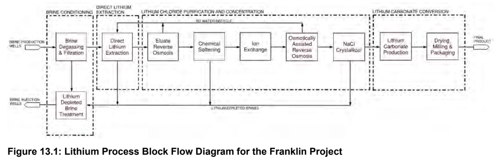

Franklin expected lithium process block flow diagram, Figure 13.1 of the 2025 resource report.

O522. [Open Figure 13.1 at PDF page 69](https://www.standardlithium.com/_resources/reports/Franklin-Project-NI-43-101-MRE.pdf?v=110803#page=69). The SWA-derived sequence includes brine pretreatment, DLE, purification/concentration and carbonate conversion. The next section recommends project-specific DLE, pretreatment and downstream test work. It supplies no complete measured stream balance. Potential bromine/potash circuits are discussed separately in §13.6; they should not be assumed part of a validated lithium plant.

### Newer PEA basis

The September 8, 2026 announcement models 20 years on a 100%-project basis. **668 mg/L** above remains the older exploration average; **515 mg/L** below is a modelled lifetime average.

Scroll within the table to see all columns and rows.

| Year-one Li (mg/L) | Lifetime-average Li (mg/L) | Average brine flow (bbl/d) | Capacity (tpa carbonate) | Average output (tpa carbonate) |
| --- | --- | --- | --- | --- |
| 562 O524 | 515 O523 | 455000 O525 | 70000 O526 | 64600 O527 |

The PEA is preliminary and includes inferred resources. The announcement says a supporting report will follow; that later report was not collected in this pass. It reports preliminary vendor testing without numerical recovery/rejection results sufficient for this comparison. Project-specific full water, energy and reagent balances, binding offtake and completed permitting remain gaps. D118, “Processing Overview” and technical-report statement.

### Pretreatment

H2S removal if applicable → iron precipitation → suspended-solids filtration recommended for testing. Optional bromine route additionally needs bisulfite treatment and partial ammonia neutralization. Expected / recommended train; optional co-product circuit kept separate from lithium-only case. O583, O584

Compare pretreatment methods across all projects.

## Wellspring Hydro / LibertyStream, North Dakota

**Disclosure summary:** government-hosted applicant proposal and high-level process drawing; no complete project-feed composition established. This profile covers a **distributed field program**, not a single fully identified commercial plant. **Cutoff: September 16, 2026.**

Triple 8 LLC, doing business as Wellspring Hydro, proposes produced-water DLE and carbonate validation with LibertyStream Infrastructure Partners. The August 31, 2025 application names more than ten North Dakota saltwater-disposal facilities but offers site details upon request. Earlier R-50-67 Prairie Lithium work is separate from the R-56-78 LibertyStream program. O528; D120.

### Chemistry and validation

The application describes a tenfold LiCl concentration step but does not establish a full feed assay with major ions, dated samples and detection limits. Its “Lithium Value of Basins” graphic is not a site-specific feed-water analysis. The **99.5% carbonate purity** is a validation objective, not an accepted product assay. O530; D115, pp. 1, 20.

Scroll within the table to see all columns and rows.

| Item | Source basis | Interpretation |
| --- | --- | --- |
| Grant listing | US$500,000, R-56-78. O531 | Award, not proof of disbursement or completed performance |
| Water/waste balance | Requested output in application p. 10 | Completed results not supplied in the selected proposal |
| Site-specific feed, recovery, energy and cost | Not established from this package | Do not substitute generic basin or technology claims |

### High-level process drawing

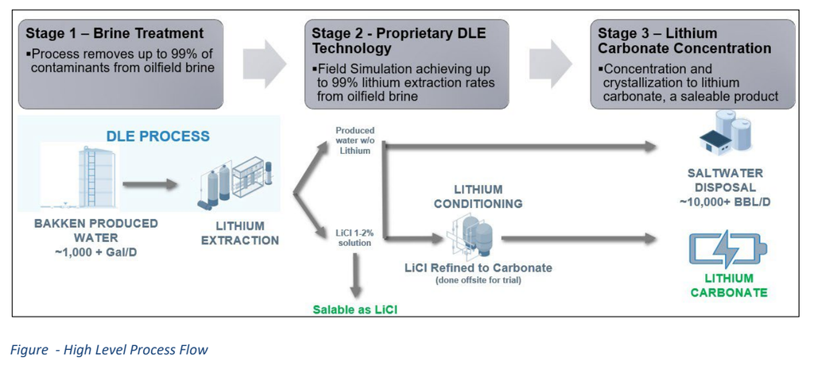

Wellspring high-level process drawing from the North Dakota grant application, PDF page 21.

O529. [Open the source at PDF page 21](https://www.ndic.nd.gov/sites/www/files/documents/Renewable-Energy-Program/Grant-Rounds--Final-Reports/Proposals/Grant-Rounds-59-50/R-56-A-Unlocking-Lithium-Carbonate-in-Produced-Wat.pdf#page=21). The drawing shows brine treatment, DLE and carbonate conversion; it labels trial refining as off site. Its approximate 1,000+ gal/day feed and 10,000+ bbl/day disposal labels use different scales and do not form a closed balance. The drawing makes two separate “up to 99%” claims: Stage 1 contaminant removal and Stage 2 lithium extraction. Neither is supported here by the species-specific or recovery test series needed to accept it as project performance. O585. Current permitting, measured outcomes, construction, economics and offtake need follow-up.

### Pretreatment

Brine-treatment block and proposed site-specific technology selection; exact train not established. Species-specific targets, reagents and outlet limits are not supplied in selected passages. Applicant proposal. Carbonate-refining precipitation/filtration is downstream of DLE. O585, O586

Compare pretreatment methods across all projects.

## Anson / A1 Lithium Paradox

**Disclosure summary:** 18 proposed chemistry parameters in a May 2024 draft UIC package. The ranges match Green River exactly and have an unresolved stream label. **Cutoff: September 16, 2026.**

A1 Lithium’s Paradox development west of Moab in Grand County, Utah, is separate from Anson/Blackstone Green River. The agency notice identifies **UTU-37-AP-1D61E74**. “A1 Lithium LLC” and “A1 Lithium Inc.” occur as source-name variants. The collected public notice and permit are draft-stage evidence; final authorization was not verified. D114, D123.

### Full published permit chemistry

The Table D-1 heading calls this production brine, while the operating plan calls it spent brine after lithium/bromide removal and rinse-water dilution. All values repeat Green River’s draft table. These are **proposed permit ranges**, not two independent feed-water assays. Retain ppm without converting it to mg/L.

Scroll within the table to see all columns and rows.

| Parameter | Published range (ppm) | Evidence |
| --- | --- | --- |
| Lithium | 170–210 | O532 |
| Bromine | 3500–4000 | O533 |
| Boron | 1400–1700 | O534 |
| Sodium | 18000–20000 | O535 |
| Potassium | 25000–29000 | O536 |
| Calcium | 45000–50000 | O537 |
| Magnesium | 35000–40000 | O538 |
| Chloride | 220000–260000 | O539 |
| Iron | 200–250 | O540 |
| Sulfate | 50–100 | O541 |
| Strontium | 1500–1800 | O542 |
| Barium | 1–4 | O543 |
| Zinc | 3–4 | O544 |
| Bicarbonate | 1200–1400 | O545 |
| Fluoride | 30–35 | O546 |
| TDS | 350000–400000 | O547 |

Scroll within the table to see all columns and rows.

| Density (g/cm³) | pH (dimensionless) | Evidence |
| --- | --- | --- |
| 1.27–1.28 | 4.5–5.0 | O548, O549 |

[Open Table D-1 at PDF page 48](https://www.utah.gov/pmn/files/1126711.pdf#page=48). Sample dates, methods, detection limits and separately identified feed/eluate/effluent analyses are missing from this table.

### Injection scope and process gaps

The draft operating plan gives **2,000 gpm overall and 300 gpm per well** as injection ceilings. These are proposed limits, not achieved plant throughput; the combined-flow and well-count basis require confirmation. O550.

A complete DLE-to-product flowsheet and measured water balance were not located in the reviewed injection-permit package. Recovery, purity, utility demand, reagents, emissions, costs, funding, offtake and commissioning were not established in this focused addition. Wider Anson corporate/project studies remain to collect; the draft chemistry is not a substitute for them.

### Pretreatment

No upstream DLE pretreatment train established in reviewed injection package. Shared Green River chemistry does not identify a treatment recipe. Draft spent-brine management cannot substitute for an upstream process flowsheet. D114, Attachment D, PDF pp. 46–48.

Compare pretreatment methods across all projects.

## US Magnesium / International Battery Metals

**Historical profile; cutoff September 16, 2026.** Utah Geological Survey’s *Utah Mining 2024* records DLE installation in mid-2024 using International Battery Metals technology, followed by idling of US Magnesium operations in late 2024. This is a separate Great Salt Lake operation from Ogden and Waterleaf. The survey draws partly on company information and does not establish a current restart. O551.

### Chemistry and process evidence

Scroll within the table to see all columns and rows.

| Question | Located evidence | Limit |
| --- | --- | --- |
| Lithium source | Byproduct material from magnesium production | Not equivalent to untreated lake water |
| DLE product | Intended high-grade lithium chloride | No project-specific product assay in this survey passage |
| Capacity | Approximately 10,000 t/year carbonate target for the operation | Not measured output of the IBAT installation |
| Full water composition / flowsheet | Not located in selected survey | Operator technical package and permits still needed |

The agency summary identifies a historical installation, not a complete engineering record. No direct feed assay, full numbered-stream balance, validated recovery, consumption data, economics or current offtake was established in this addition. D116, printed p. 15 / PDF p. 21.

### Pretreatment

DLE installation on magnesium-operation byproduct material; specific preparation train not established. Prior magnesium processing changes the feed, but the survey does not detail DLE pretreatment. Historical government-survey summary; no transfer of Ogden or Waterleaf methods. O551.

Compare pretreatment methods across all projects.

## Mandrake Utah Lithium Project

**Exploration/testing profile; cutoff September 16, 2026.** Mandrake’s Lisbon Valley project in San Juan County, Utah, is separate from Anson’s projects. Electroflow is a DLE testing partner, not a second mineral project counted here. D116, PDF p. 22; D124.

### Concentration and test status

Scroll within the table to see all columns and rows.

| Li (mg/L) | Basis | Evidence |
| --- | --- | --- |
| 69–142 | Estimated average grades across resource horizons; not a current DLE-feed assay | O552 |

The September 15, 2026 issuer announcement reports approximately **8,000 L** collected from Evelyn Chambers #1’s existing Leadville perforations and transferred to Electroflow for appraisal. Purity, recovery and costing results are future outputs in that announcement. The wording “bulk brine production complete” refers to sample collection, not commercial lithium production. O553.

No full chemistry panel for that delivered brine, complete process flowsheet or measured water/energy balance was found in these selected records. UGS summarizes a 3.6 Mt LCE resource, whereas the issuer update says 3.3 Mt; the discrepancy needs the underlying dated resource reports. These figures are not used to rank projects. D116, D124.

### Pretreatment

Brine supplied to Electroflow for appraisal; pretreatment selection not established. No full treatment train, reagent schedule or inlet/outlet pair in the cited update. Sample delivery is not completed pretreatment validation. O553.

Compare pretreatment methods across all projects.

## TETRA / Saltwerx Evergreen

**Limited development profile; cutoff September 16, 2026.** Evergreen is distinct from Exxon/Saltwerx Pine and SWA’s Reynolds unit. TETRA’s SEC annual report describes the unit and potential bromine/lithium development. The neighboring-property section of SWA’s DFS reports TETRA as operator with 65% working interest and Saltwerx with 35%. O554, O555.

### Unit history and chemistry gaps

Scroll within the table to see all columns and rows.

| Record | Reported scope | Limit |
| --- | --- | --- |
| 2023 unit history | Approximately 6,138 acres, described in TETRA’s 10-K | Direct AOGC orders not collected |
| April 2025 expansion | 6,953 acres in SWA DFS §23.3 | Later footprint, not a contradictory measurement of the same vintage |
| Development | Bromine plant work; lithium validation still prospective in the 10-K | Bromine progress is not achieved lithium output |
| Full feed chemistry / lithium flowsheet | Not extracted in this addition | Underlying TETRA technical studies and unit-specific permits are priority follow-up |

No unit-specific concentration is presented here. The 10-K refers to updated technical studies, but those studies were not collected for this addition. Do not assign SWA brine chemistry or recovery to Evergreen merely because TETRA and Saltwerx appear in both regional histories. D121, mineral-resource discussion; D044, §23.3.

### Pretreatment

No lithium-specific pretreatment train established in the currently collected unit/development records. Bromine development alone does not specify the future lithium-feed preparation. Underlying TETRA technical studies remain uncollected; no process inferred from neighboring SWA. O554, O555.

Compare pretreatment methods across all projects.

## ExxonMobil / Saltwerx Pine

**Limited identity/permitting-history profile; cutoff September 16, 2026.** The SEC-filed SWA DFS and its saved issuer PDF identify Saltwerx, acquired by ExxonMobil, and the **Pine brine unit** in Miller and Lafayette counties, Arkansas. The record reports April 2025 unitization of **56,245.58 acres**. The direct AOGC order was not collected. O556; D001, D044, §23.2.

### Project boundary and disclosure gaps

Scroll within the table to see all columns and rows.

| Question | Evidence boundary |
| --- | --- |
| Which project? | Pine unit, separate from TETRA-operated Evergreen and SWA Reynolds |
| Historical acreage | Earlier 120,000 gross mineral acres describes a larger Saltwerx lease position |
| Brine concentration / full composition | No Pine-specific table extracted from this neighboring-property record |
| DLE flowsheet / water balance | No Pine-specific engineering package collected in this addition |

This profile establishes a distinct development record. It does not establish measured recovery, product purity, commercial operation or all required approvals. Direct Exxon technical disclosures, unit orders and environmental submissions remain the next evidence targets. Historical ownership or aliases are not counted as extra projects.

### Pretreatment

No Pine-specific pretreatment train established in the collected unit-identity record. Targets, chemistry, filters and outputs unresolved. Direct Exxon project engineering evidence still needed. O556.

Compare pretreatment methods across all projects.

## EnergyX / EXSO Lonestar, Texas

**Limited securities profile; cutoff September 16, 2026.** The July 2026 SEC circular identifies EXSO’s Northeast Texas options and a commissioned demonstration plant in leased industrial space. Option rights are conditional; commissioning does not establish commercial production. O557.

### Chemistry and scope

Scroll within the table to see all columns and rows.

| Evidence sought | Result of this addition |
| --- | --- |
| Project-specific dated feed assay | Not established |
| Full water composition | Not established |
| Site-specific flowsheet and closed balance | Not established |
| Source | SEC circular, “Project Lonestar,” printed p. 46; web text only |

Some corporate wording uses Lonestar across Texas and Arkansas; this page follows the Texas assets, while Daytona follows the acquired Arkansas leases. Generic technology tests and combined production ambitions are not assigned to either site’s measured performance. Local permit and technical packages remain to collect. D089.

### Pretreatment

No site-specific pretreatment train established in the selected Texas project disclosure. Generic LiTAS or multi-project claims are not a Texas treatment specification. Commissioned demonstration does not itself document the pretreatment train. O557.

Compare pretreatment methods across all projects.

## EnergyX Daytona / Folsom Point, Arkansas

**Limited acquisition/development profile; cutoff September 16, 2026.** EnergyX’s SEC circular reports the October 1, 2025 acquisition of Daytona Lithium Pty. Ltd. from Pantera, including Folsom Point Energy LLC and its Southwest Arkansas mineral leases. This page separates those assets from Texas Lonestar; it does not imply a wholly independent technology platform. O558.

### Chemistry and process disclosure

Scroll within the table to see all columns and rows.

| Evidence sought | Result of this addition |
| --- | --- |
| Measured project-feed lithium | No dated assay established; regional targeting language is insufficient |
| Full water composition / flowsheet | Not established in the selected filing sections |
| Development status | Acquisition and development disclosure, not commercial operating evidence |
| Direct permits and technical studies | Not collected |

The filing identifies LiTAS as the intended technology but does not supply a site-specific closed water balance. Recovery, consumptions, costs and offtake require project-specific records. D089, “Daytona Lithium Pty. Ltd. Acquisition,” printed p. 46.

### Pretreatment

No Arkansas asset-specific pretreatment train established in the selected acquisition disclosure. Targets, reagents and treated-feed assays unresolved. Do not inherit Texas or Ogden methods merely through shared ownership. O558.

Compare pretreatment methods across all projects.

## Albemarle Magnolia DLE pilot

**Issuer-supported profile; direct government package still needed. Cutoff: September 16, 2026.** Albemarle’s 2024 sustainability report says DLE piloting began at Magnolia, Arkansas, in 2024, using a different brine and extraction technology from its La Negra pilot in Chile. O559.

### Chemistry and evidence limits

Scroll within the table to see all columns and rows.

| Question | Located evidence | Limit |
| --- | --- | --- |
| Pilot identity | Magnolia, Arkansas; 2024 piloting statement | Issuer report, not an agency approval |
| Brine concentration / full composition | Not located in the cited pilot passage | Regional or other-site chemistry is not substituted |
| Full flowsheet / water balance | Not located in this source | Direct technical and permit records still needed |

The Chile recovery claim on the same source page is not a Magnolia result. Regional bromine production and site-wide sustainability metrics likewise cannot establish DLE water or emissions intensity. The SWA DFS’s neighboring-property description supplies context but not direct Magnolia engineering evidence. D122, PDF p. 46; D044, §23.1.

### Pretreatment

Pilot statement does not disclose a Magnolia-specific pretreatment train. Different brine/technology from La Negra; no Chile method or efficiency transferred. Issuer-only pilot evidence; direct government/technical package missing. O559.

Compare pretreatment methods across all projects.

## Standard Lithium / LANXESS commercial history

**Historical commercial profile with separate demonstration evidence. Cutoff: September 16, 2026.** Standard Lithium’s 2025 annual information form says the LANXESS commercial MOU ended by mutual agreement in 2025 and the company stopped pursuing that property development. It separately describes continued demonstration work near the South plant in El Dorado, Arkansas. O560.

### Existing demonstration chemistry

Scroll within the table to see all columns and rows.

| Li (mg/L) | Stream / date | Evidence |
| --- | --- | --- |
| 237 | Post-bromine-extraction demonstration feed, May 4–June 30, 2023 average | Existing O120, full 11-parameter column |

The same demonstration table is already included under SWA as supporting process research; it is linked here without creating a duplicate measurement set. Its chemistry is not representative of SWA raw brine and does not prove commercial LANXESS 1A operation. D044, Table 13-1; D117, Table 13.1 note 2.

Historical standalone commercial studies and a complete current demonstration stream balance were not added in this pass. Project cessation and continued pilot work are different events; preserve both when interpreting schedules, capacity, economics and offtake. D119, “Other Projects.”

### Pretreatment

Post-bromine feed with upstream phase separation/vacuum degassing; pH/ORP, temperature and filtration trials. UF, multimedia, activated carbon, walnut-shell and iron-guard-bed options tested; not all selected. Demonstration supports SWA research; not proof that the ended commercial project was built. O567, O566

Compare pretreatment methods across all projects.

# Brine chemistry comparison

Each row retains its own stream, date and evidence basis. **Li (mg/L) and Li (ppm) are separate source units.** A blank entry is not zero. Product eluate is shown separately; values are not ranked as project performance.

## Reported brine measurements

Scroll within the table to see all columns and rows.

| Project | Stream / basis | Li (mg/L) | Li (ppm) | Sample or study date / source |
| --- | --- | --- | --- | --- |
| SWA | Pilot-feed average · reported measurement | 476 | — | Oct 2024–Jan 2025 · O109 |
| BHER | Brine laboratory average · reported measurement | — | 222 | Sample dates not reported; 2024 report · O144 |
| Ogden | Lake location/depth averages · reported measurements | 25.9–58.6 | — | 2020–H1 2021 · O251, O266; complete table in project |
| Ogden | Pond 114 individual samples · reported measurements | 125–328 | — | March 3, 2020 · O314, O338; concentrated pond feed |
| Waterleaf | Pilot raw brine · selected stable-period average | 69 | — | 2025 pilot, weeks 16–28 · O407 |
| Franklin | Exploration sample average · reported measurement | 668 | — | 2023 samples / 2025 report · O512 |
| LANXESS history | Post-bromine demonstration feed · also cited under SWA | 237 | — | May–June 2023 · O120; not independent SWA-feed evidence |

## Expected, design, resource and permit values

Scroll within the table to see all columns and rows.

| Project | Stream / basis | Li (mg/L) | Li (ppm) | Study date / source |
| --- | --- | --- | --- | --- |
| Hell’s Kitchen | Expected geothermal composition · assay/stream point unresolved | 250 | — | 2023 EIR · O051 |
| BHER | Process-diagram brine value · separate approximate basis | — | approximately 250 | 2024 report · O192 |
| Mandrake Utah | Resource-horizon average grades · not delivered DLE-test feed | 69–142 | — | 2024 resource summary · O552 |
| SWA | Commercial process-design feed | 439.9 | — | 2025 DFS · O009 |
| Waterleaf | Raw-brine stream 3101 · commercial model | 68.0 | — | February 2026 application · O683 |
| Franklin | Plant-life average · economic/resource model | 515 | — | September 2026 PEA · O523 |
| Franklin | Year-one concentration · economic/resource model | 562 | — | September 2026 PEA · O524 |
| Green River | Proposed permit chemistry · production/spent-brine label unresolved | — | 170–210 | November 2023 draft · O385 |
| Paradox | Proposed permit chemistry · repeats Green River ranges | — | 170–210 | May 2024 draft · O532; not an independent assay |

## Lithium-rich product streams

Scroll within the table to see all columns and rows.

| Project | Stream / basis | Li (mg/L) | Sample or study date / source |
| --- | --- | --- | --- |
| Waterleaf | Pilot DLE eluate · selected stable-period average | 2044 | 2025 pilot, weeks 16–28 · O408 |

## Projects with chemistry gaps

ATLiS, Wellspring, US Magnesium, Evergreen, Pine, Lonestar, Daytona and Magnolia do not have a comparable project-feed lithium assay established in the collected records. Each has a dedicated project profile; the 18-project disclosure table identifies the specific gap. A full published table reproduces all its listed rows; it is not a claim of exhaustive water chemistry.

# Published process flowsheets

Source figures from eight project profiles. These are block/process drawings with differing scope; no complete measured stream-by-stream balance was established. All-project disclosure coverage includes projects without a published figure in this report.

## South West Arkansas

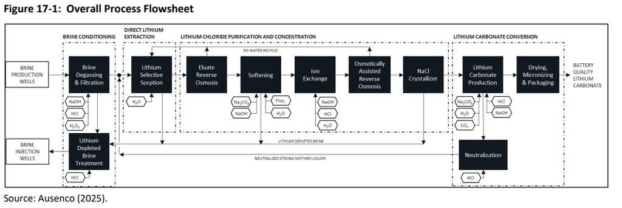

SWA overall process flowsheet, Figure 17-1 from the 2025 DFS.

Process, original source and limitations

## South West Arkansas

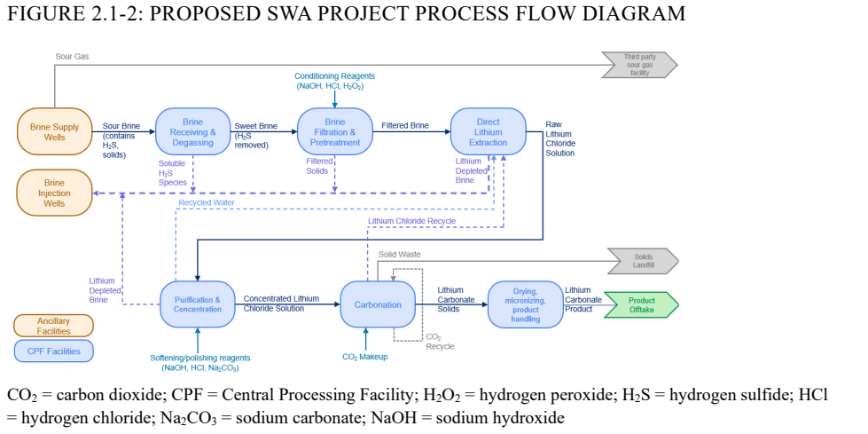

SWA project process flow diagram, Figure 2.1-2 from the May 2026 DOE environmental assessment.

Process, original source and limitations

## Hell’s Kitchen

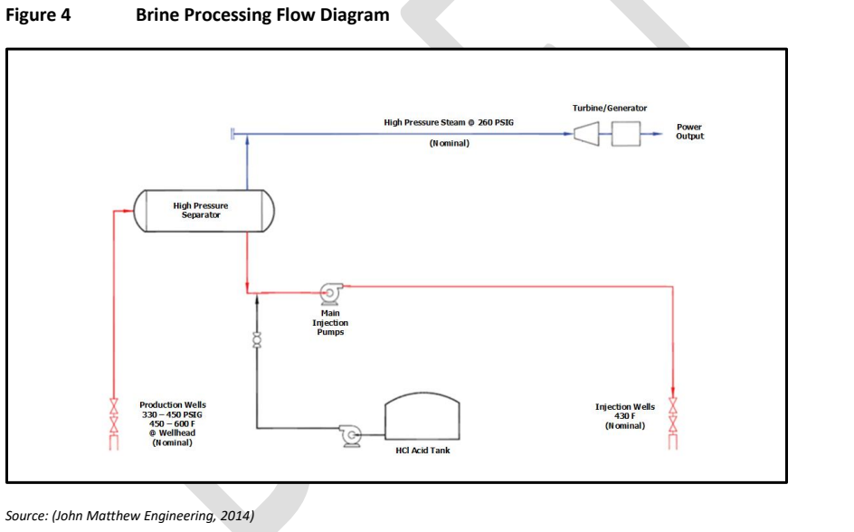

Hell’s Kitchen geothermal brine-processing schematic, Figure 4 in the air-quality appendix.

Process, original source and limitations

## BHER demonstration

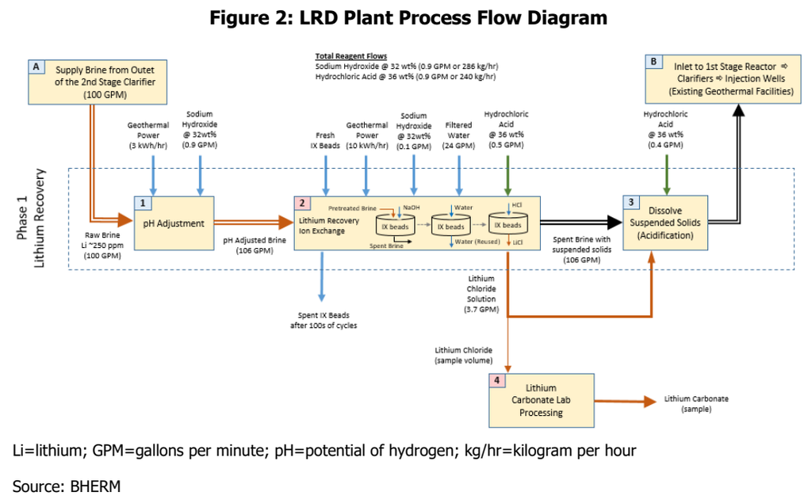

BHER demonstration process diagram, Figure 2, CEC-500-2024-094; design annotations, not achieved operating data.

Process, original source and limitations

## ATLiS

[figure not shown]

ATLiS NEPA process flow diagram, Figure 4 of the March 2025 DOE EA; source EnergySource Minerals.

Process, original source and limitations

## Ogden / Great Salt Lake

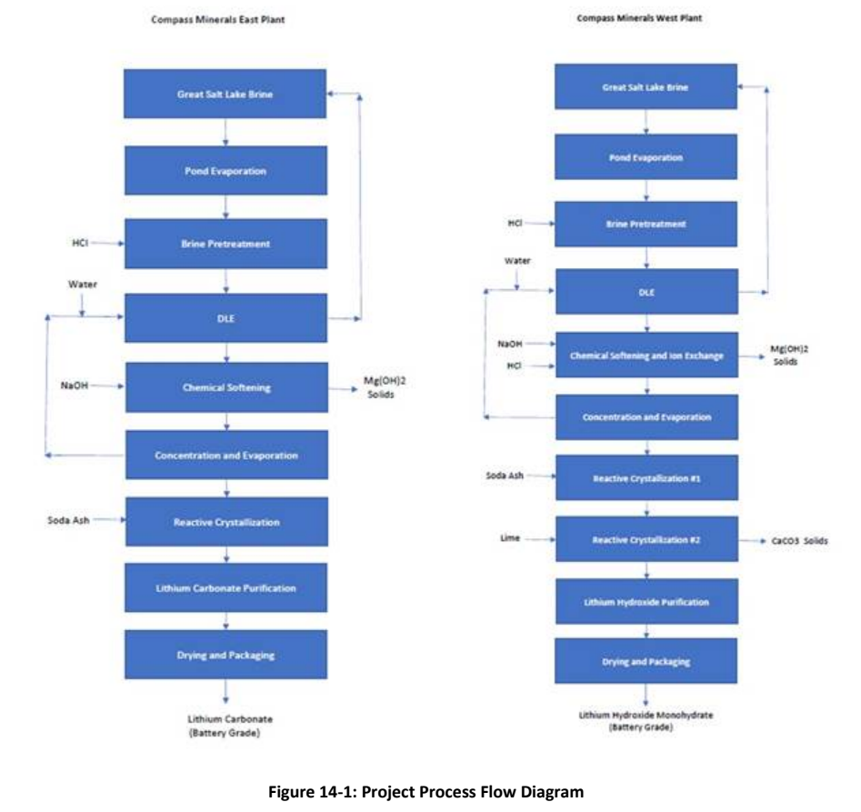

Ogden East and West process block flowsheets, Figure 14-1 of the 2022 Compass Minerals technical report.

Process, original source and limitations

## Waterleaf / Lilac

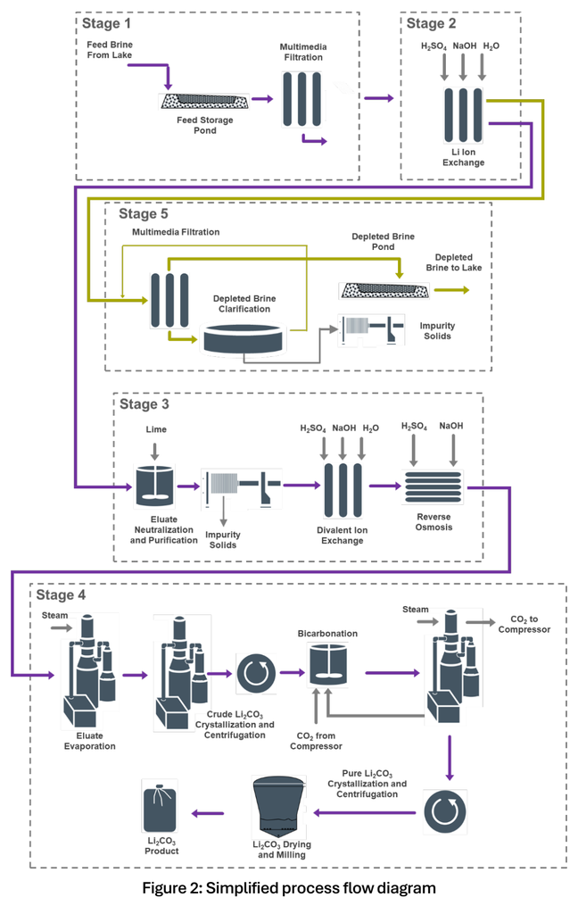

Waterleaf simplified commercial process flow diagram, Figure 2 of the operations application.

Process, original source and limitations

## Waterleaf numbered outfall streams

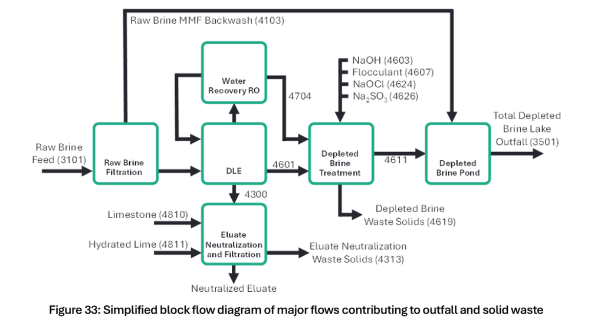

Waterleaf Figure 33, numbered outfall and waste streams; commercial design, linked to Table 23.

Numbered flowsheet, flows and chemistry

## Franklin

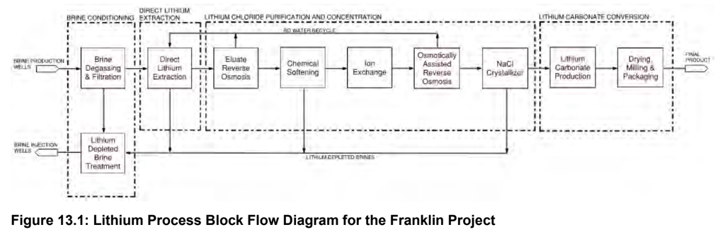

Franklin expected lithium process block flow diagram, Figure 13.1 of the 2025 resource report.

Process, original source and limitations

## Wellspring

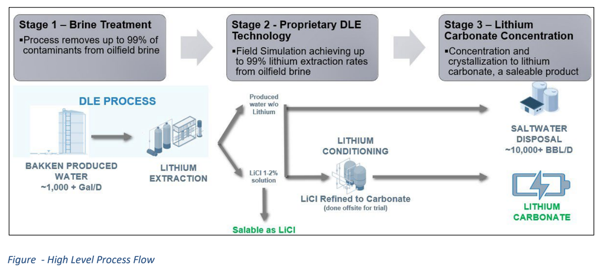

Wellspring high-level process drawing from the North Dakota grant application, PDF page 21.

Process, original source and limitations

# Cross-project comparison

This original-pilot engineering comparison covers SWA and Hell’s Kitchen. The 18-profile disclosure coverage and brine chemistry comparison have separate views. The table preserves source definitions. It does not convert products, normalize water intensity, or calculate a comparative environmental ranking.

Scroll within the table to see all columns and rows.

| Topic | South West Arkansas | Hell’s Kitchen | Comparability |
| --- | --- | --- | --- |
| Brine lithium | 439.9 mg/L; September 2025 process-design basis. O009 | 250 mg/L; August 2023 expected geothermal composition. O051 | Different source basis; exact HK stream point and assay provenance unspecified. |
| Product/capacity | 22,500 t/year carbonate; September 2025 commercial design. O004 | 25,000 TPA LCE; August 2026 Stage 1 target. O069 | Different vintage and evidential basis; product conventions require checking. |
| Recovery | >95% reported demonstration/pilot extraction; 89.25% commercial whole-process design, September 2025 DFS. O002, O003 | Not established in screened 2023 environmental text. O050 | No performance ranking. |
| Freshwater | Commercial estimates: 3.17 million m³/year, September 2025 DFS; 1,600–1,700 gpm CPF, May 2026 EA. O016, O017 | August 2023 design: 6,100 or 6,300 AFY HKL1; approximately 6,500 AFY combined. O055–O057 | Reconcile source differences, boundaries and operating hours first. |
| Electrical demand | 40,008 kWe CPF + wellfield; September 2025 commercial design. O020 | Approximately 35 MW average HKL1 demand, alongside 49.9 MW generation; August 2023 design. O052, O053 | Consumption boundaries differ; generation is a separate quantity. |
| GHG | 290,000 tons/year potential emissions; May 2026 commercial-facility estimate. O033 | −10,435 metric tons/year net combined estimate; August 2023 EIR. O063 | Gross/potential and net/credited accounting; unresolved ton conventions. |
| Operating costs | US$4,516.05/t LCE, Q1 2025 cost basis; initial commercial-phase model. O035 | August 2026 expansion model; unit/basis unresolved. O072 | No cost ranking. |
| Development | DOE funding FONSI, May 2026. O042 | County Board approval, January 2024. O066 | Different agency actions, not equivalent completion milestones. |

## Composition and flowsheet availability

“Full table” means all rows of a named published table, not an exhaustive chemical characterization. No complete measured stream-by-stream material/energy balance was established for the covered profiles.

Scroll within the table to see all columns and rows.

| Project / technical vintage | Li (mg/L) | Li (ppm) | Stream basis | Broader chemistry | Diagram and balance coverage |
| --- | --- | --- | --- | --- | --- |
| South West Arkansas · 2025 DFS | 476; design 439.9 | — | Measured pilot feed; separate design | 11 parameters in full two-feed table. Table | Overall block flowsheets; no complete numbered balance. Figures |
| Hell’s Kitchen · 2023 EIR | 250 | — | Expected geothermal brine | 23 expected constituents. Table | Geothermal schematic; lithium stages in narrative. Limits |
| BHER demonstration · 2024 report | — | 222; diagram approximately 250 | Laboratory-average brine; separate diagram basis | 24 brine parameters plus canal-water and steam tables. Tables | Demonstration PFD with selected flows; balance deliverable cancelled. Figure |
| ATLiS · 2021/2025 environmental studies | — | — | Complete project-specific feed assay not located | Monitoring-well chemistry is a different stream. Scope | Four-stage block diagram; brine and water estimates, no closed balance. Figure |
| Ogden · 2022 initial assessment | Lake: 25.9–58.6; Pond: 125–328 | — | Lake Table 7.2 location/depth averages; Pond 114 individual samples | Five-cation lake table and four-cation pond table; not complete water analyses. Tables | Historical East/West block flowsheets include pond evaporation. Figure |
| Green River · 2023 draft permit | — | 170–210 | Production/spent-brine label unresolved | 18 proposed parameters, including density and pH. Table | Injection manifold only, with reused copper-project provenance. Limits |
| Waterleaf · 2025 pilot / 2026 application | Pilot: 69 raw, 2044 eluate; design: 68.0 raw, 14.2 outfall | — | Selected pilot averages; separate commercial model | Six pilot constituents; eleven design-ion rows for twelve streams; separate groundwater panel. Design table | Numbered outfall/waste diagram, nominal/design stream flows and water summary; full Appendix D.4 redacted. Scope |
| Franklin · 2023 samples / 2025 report; 2026 PEA | 668 samples; 515 model average | — | Exploration average vs separate lifetime model | Ten-constituent table; no complete makeup-water analysis. Details | Expected lithium block flowsheet; no measured complete balance. Scope |
| Wellspring · 2025 grant application | — | — | Distributed produced-water program | Full site-specific feed assay not established. Details | High-level drawing mixes scales; no closed balance. Scope |
| Paradox · 2024 draft permit | — | 170–210 | Production/spent label unresolved; repeats Green River | 18 proposed parameters, not an independent measured assay. Details | Injection package; full DLE flowsheet not located. Scope |
| US Magnesium · 2024 historical events | — | — | Magnesium-operation byproduct | Feed chemistry not established in survey. Details | Historical installation; engineering package missing. Scope |
| Mandrake Utah · 2024 resource / 2026 sample collection | 69–142 | — | Resource-horizon averages; not delivered test-feed assay | Bulk-sample composition not established. Details | Electroflow appraisal prospective; no full PFD located. Scope |
| Evergreen · 2025 annual disclosure | — | — | Distinct TETRA/Saltwerx unit | Direct technical-report chemistry not yet extracted. Details | Bromine development does not establish lithium operation. Scope |
| Pine · 2025 neighboring-property disclosure | — | — | Saltwerx/Exxon unit identity | Pine-specific assay not established. Details | Direct unit/process package not collected. Scope |
| Lonestar · July 2026 SEC circular | — | — | Texas demo and mineral options | Dated feed panel not established. Details | Site-specific full PFD not located. Scope |
| Daytona / Folsom Point · July 2026 SEC circular | — | — | Acquired Arkansas leases | Regional target range excluded as a measured assay. Details | Site-specific full PFD not located. Scope |
| Magnolia · 2024 issuer pilot statement | — | — | Issuer-supported lead; government package missing | Magnolia-specific assay not located. Details | Do not transfer La Negra performance to this pilot. Scope |
| LANXESS history · 2023 demo chemistry; 2025 commercial cessation | 237 demo | — | Post-bromine demonstration feed, already counted under SWA | Existing 11-parameter column; no duplicate observations. Details | Historical commercial studies not added in this pass. Scope |

A dash means no value is presented in that unit. Do not rank these lithium values directly: ppm and mg/L are retained as distinct source units; lake, concentrated pond brine, geothermal feed and proposed injection chemistry are different boundaries. The earlier two-project engineering comparison above retains its original scope.

## Pretreatment comparison

**The filings disclose different treatment trains, not a single interchangeable “pretreatment” step.** The comparison below covers all 18 profiles, including explicit gaps. It uses the collected study vintages; no new claim of current plant operation or exhaustive historical coverage is made. The observations remain pending human review.

Here, **pretreatment means preparing the brine before it enters the lithium-selective extraction step**. Existing well-pad, geothermal or pond operations are identified as upstream feed history. Purification of lithium-rich eluate and treatment of depleted brine are separate. **“Not established” means the reviewed project records do not identify a defensible train; it does not mean the plant needs no pretreatment.**

The clearest contrasts are SWA’s gas removal, chemical conditioning and multimedia-plus-UF design; Waterleaf’s selected raw-brine multimedia filtration; ATLiS’s staged non-lithium mineral removal; and BHER’s reported response to field-test solids clogging. There is no matched dataset here for ranking their cost, water use or overall effectiveness. SWA, Waterleaf, ATLiS, BHER.

### Methods disclosed

This inventory includes selected methods and tested alternatives. It is a synthesis of the cited project descriptions, not a recommendation to combine every listed method into one plant.

Scroll within the table to see all columns and rows.

| Method / operation | Role before DLE | Where disclosed | Comparison limit |
| --- | --- | --- | --- |
| Phase separation; gas stripping/scrubbing | Separate oil/gas phases and dissolved gases. | SWA design: well-pad separation, then air stripping and H2S scrubber. LANXESS test history and Franklin co-product concept: vacuum degassing. O561, O562, O567, O584 | These are different gas-handling arrangements; no matched removal/cost data. |
| Temperature conditioning | Bring brine to the chosen extraction/process conditions. | SWA heat exchanger; HK vacuum-flash cooling. O563, O568 | Cooling is not itself proof of contaminant removal. |
| pH / oxidation-reduction adjustment | Condition brine; where stated, form removable iron solids. | SWA NaOH/H2O2; BHER NaOH pH elevation. ATLiS identifies HCl for pH control. Ogden Figure 14-1 shows pre-DLE HCl input, with duty unresolved. O576. O563, O570, O574 | Different purposes and feed chemistry; do not infer equal pH, dose or iron removal. |
| Screening, clarification and weir separation | Remove or intercept suspended/coarse material. | Waterleaf intake screens; pre-existing geothermal clarification at BHER/ATLiS; BHER added weir tank after clogging. O577, O571, O573 | Solids separation alone does not establish removal of dissolved salts. |
| Solar evaporation and salt precipitation | Concentrate brine and remove salts before it reaches the DLE plant. | Ogden’s historical pond and salt-recovery operations prepare distinct feed streams. O575 | Existing upstream operations, not a dedicated DLE pretreatment unit; pond history changes the inlet chemistry. |
| Multimedia filtration | Filter suspended matter; SWA also names residual oil droplets. | Selected for Waterleaf; precedes UF in SWA. O577, O564 | Waterleaf’s short cold-brine test is not a universal advantage over UF. |
| Ultrafiltration: pressurized/submerged, polymeric/ceramic options | Membrane solid–liquid separation before extraction. | SWA selects UF after multimedia; LANXESS tests pressurized/submerged UF; Waterleaf tests polymeric/ceramic UF. O564, O566, O578 | Plant selection differs. Waterleaf reports winter flux penalties; SWA retains UF in its own design. |
| Precoat filtration | An evaluated filtration alternative. | Waterleaf lists it among tested incoming-brine options. O578 | Not selected as its main raw-brine filter; a separate downstream filter press must not be mistaken for the same stage. |
| Activated carbon, walnut-shell filters and iron guard beds | Hydrocarbon-removal / residual-iron options in the test program. | Listed in LANXESS-site demonstration tests supporting SWA. O566 | No like-for-like performance table; source says many tested options were sub-optimal. |
| Staged mineral removal with solids dewatering | Remove targeted non-lithium minerals before DLE. | ATLiS: Fe/silica then Mn/Zn removal on the brine path; separated solids go to filter presses. HK: proprietary silica/polymetallic removal and filtration. O573, O569 | Detailed reaction recipes are incomplete; waste versus potential product disposition differs. |
| Conditional dehalogenation / neutralization | Prepare bromine-depleted brine for lithium extraction. | Franklin co-product concept: sodium bisulfite after bromine extraction, then partial neutralization with anhydrous ammonia. O584 | Optional bromine pathway, not a confirmed requirement for the lithium-only project. |

### Project-by-project comparison

**Design** describes the proposed commercial train; **test history** describes reported trials; **recommended work** is prospective. A method listed in a test program is not automatically a commercial selection. Open a project for reagent details, residuals, source locators and qualifications.

Scroll within the table to see all columns and rows.

| Project / source vintage | Incoming-brine treatment or gap | Evidence basis |
| --- | --- | --- |
| SWA · 2025 DFS / 2026 EA | Well-pad phase separation → air stripping/scrubbing → cooling → pH/ORP conditioning → multimedia filtration → UF. | Selected commercial design; supporting trials |
| Hell’s Kitchen · 2023 EIR | Vacuum-flash cooling → proprietary silica/polymetallic recovery and filtration → lithium extraction. | Proposed sequence; proprietary chemistry |
| BHER demonstration · 2022–2023 | Existing secondary clarification → NaOH pH adjustment; weir tank acquired after initial solids clogging. | Field-test response; later media degradation also observed |
| ATLiS · 2021 EIR / 2025 EA | HR1 post-secondary-clarifier brine → Fe/silica removal → Mn/Zn removal → ILiAD. Separated solids → filter-press dewatering. | Commercial proposal; no verified operating efficiency |
| Ogden · historical 2022 design | Evaporation ponds and prior salt recovery → brine filtration / pretreatment with a disclosed HCl input → ILiAD. | Historical 2022 Compass design |
| Green River · 2023 draft UIC | No upstream DLE pretreatment train established in reviewed injection package. | Not established in collected draft injection package |
| Waterleaf · 2025 tests / 2026 application | Intake screening → surge storage → raw-brine multimedia filtration. | Selected design; pilot and short cold-brine tests |
| Franklin · 2025 report / 2026 PEA | H2S removal if applicable → iron precipitation → suspended-solids filtration recommended for testing. | Recommended tests; optional bromine route is separate |
| Wellspring · 2025 application | Brine-treatment block and proposed site-specific technology selection; exact train not established. | Site-specific qualification proposed |
| Paradox · 2024 draft UIC | No upstream DLE pretreatment train established in reviewed injection package. | Not established in collected draft injection package |
| US Magnesium · 2024 historical events | DLE installation on magnesium-operation byproduct material; specific preparation train not established. | Historical installation; train not established |
| Mandrake Utah · September 2026 testing update | Brine supplied to Electroflow for appraisal; pretreatment selection not established. | Sample appraisal; selection not established |
| Evergreen · 2025 disclosures | No lithium-specific pretreatment train established in the currently collected unit/development records. | Not established in collected unit records |
| Pine · 2025 neighboring-property disclosure | No Pine-specific pretreatment train established in the collected unit-identity record. | Not established in collected unit records |
| Lonestar · July 2026 filing | No site-specific pretreatment train established in the selected Texas project disclosure. | Not established in selected Texas disclosure |
| Daytona / Folsom Point · July 2026 filing | No Arkansas asset-specific pretreatment train established in the selected acquisition disclosure. | Not established in selected Arkansas disclosure |
| Magnolia · 2024 issuer report | Pilot statement does not disclose a Magnolia-specific pretreatment train. | Issuer pilot statement; train not established |
| LANXESS history · 2020–2025 demonstration | Post-bromine feed with upstream phase separation/vacuum degassing; pH/ORP, temperature and filtration trials. | Demonstration test history; not all options selected |

### Conditions and outcomes that can actually be checked

BHER’s process description gives a pH change; Waterleaf gives a short filtration test. They measure different things and should not be ranked against one another.

Scroll within the table to see all columns and rows.

| Project / basis | Feed pH (dimensionless) | Conditioned pH (dimensionless) | Reagent / evidence |
| --- | --- | --- | --- |
| BHER demonstration process, 2022–2023 | 4.7 | 7.5 | NaOH; process description, not proof of sufficient impurity removal. O570 |

Scroll within the table to see all columns and rows.

| Waterleaf test location / scale | Feed temperatures (°C) | Flux (L/m²/h) | Duration (h) | Pressure result (psi differential) | Filtrate particle-size result (µm) |
| --- | --- | --- | --- | --- | --- |
| Oakland pilot-scale column; application pp. 106–107 | 13 and 1.5 | 12000 | 12 | Below the 5 psi design ceiling; 5 is not the measured operating pressure | No particles above 4 reported in the tested filtrates |

Waterleaf sources: O579, O580, O581. The GSL pilot performance period excluded the coldest months; the separate Oakland test supplied cold-brine evidence. Particle size is not TSS concentration, and a 12-hour test does not demonstrate seasonal media life, cleaning demand or full-scale reliability. The applicant’s narrative attributes UF difficulties to cold-brine viscosity and lower flux; it does not publish a matched lifecycle-cost comparison in these passages. O578.

BHER’s first field trial stopped after precipitated solids clogged valves and contaminated media; a weir tank was then acquired. Later tests also identified media structural degradation, and the report highlights iron/silicon removal as an unresolved need. These findings support attention to pretreatment but do not isolate it as the sole cause of failure. O571, O572.

### Keep downstream treatment separate

Scroll within the table to see all columns and rows.

| Project / stream | Treatment after DLE | Why it is excluded from incoming-brine pretreatment |
| --- | --- | --- |
| SWA concentrated eluate | NaOH/soda-ash Ca/Mg precipitation, clarification and polishing | Acts after lithium extraction and eluate RO. O565 |
| Waterleaf eluate | Neutralization and divalent-ion purification | Conditions the lithium-rich product stream, not raw lake water. O582 |
| Waterleaf depleted brine | pH adjustment, NaOCl manganese precipitation, residual-oxidant neutralization with sodium sulfite and solids removal | Prepares discharge after extraction; do not put these reagents in the raw-MMF recipe. O582 |
| Wellspring LiCl feed to carbonate unit | Precipitation and filtration designed for carbonate refining | Vendor feedstock had already passed through DLE. O586 |
| BHER loaded media / depleted brine | Wash, acid elution and depleted-brine acidification | These are extraction-cycle or return-stream operations. O570 |

For a quantitative pretreatment ranking, the remaining requirements are matched inlet/outlet analyses, lithium loss across each stage, removal efficiency by species, reagent dose per volume of brine, wash/backwash demand, filter flux and cleaning history, residual mass/disposal route, and costs at a common operating scale. **No complete, comparable set was established across the 18 profiles.** Retaining the exact stream is essential: a DLE impurity-rejection percentage or final-product purity is not a pretreatment removal percentage.

## Brine concentration and chemistry

**The principal design figures are 439.9 mg/L lithium for SWA and 250 mg/L for HK.** The first belongs to SWA’s process-design basis; the second is labeled expected geothermal brine composition in the EIR. Preserve those descriptions when using the numbers. The HK value is not established as a measured concentration at the inlet to the lithium extraction equipment. O009, O051.

Scroll within the table to see all columns and rows.

| Constituent | SWA process design (mg/L), September 2025 | HK expected composition (mg/L), August 2023 |
| --- | --- | --- |
| Lithium, Li | 439.9 O009 | 250 O051 |
| Magnesium, Mg | 3,361.2 O010 | 50 O089 |
| Calcium, Ca | 39,051.1 O011 | 29,000 O080 |
| Boron, B | 296.6 O012 | 350 O078 |
| Total dissolved solids | 370,121 O013 | Not listed as a total in Table 2.0-2 |

Sources: D044, Table 17-1, printed p. 120 / PDF p. 142; D022, Table 2.0-2, printed pp. 2.0-10–11 / PDF pp. 64–65. HK’s table additionally reports chloride, sodium, potassium, silica, iron and other constituents, retained individually in the appendix. A missing total is not a zero, and the reported species have not been summed into an inferred TDS measurement. O075–O096.

For a direct unit interpretation, 439.9 mg/L means **0.4399 kg of contained lithium per m³ of brine**, and 250 mg/L means **0.250 kg/m³**, before extraction losses. These are unit conversions, not recovered-product yields. Lithium concentration, total dissolved solids and final lithium-carbonate purity are different quantities. We retain mg/L rather than treating it as mass-based ppm without a brine density.

SWA also discloses **actual well-sampling results**. Selected reported values below retain their intervals and averaging basis; they are not averaged across wells into an invented project grade.

Scroll within the table to see all columns and rows.

| Well | Sampling year(s) | Interval | Li (mg/L) | Basis |
| --- | --- | --- | --- | --- |
| Taylor, Beulah et al. 1 | 2023 | Upper Smackover | 549 | Porosity-thickness-weighted value. O097 |
| Carter Moore 1 | 2023 | Upper + Middle | 156 | Mixed-interval test value. O098 |
| International Paper Co. 1 | 2024–2025 | Upper Smackover | 479 | Reported well average from later sampling. O099 |
| Speer 1 | 2023 | Upper / top of Middle | 589 | Reported test average. O100 |
| Montague 1 | 2023 | Upper Smackover | 555 | Reported test average. O101 |
| Lester 2 | 2025 | Upper Smackover | 582 | Reported three-sample average. O102 |
| International Paper Co. 1 | 2023 | Middle Smackover | 306 | Reported weighted zone average. O103 |

These data are reported in D044, Table 9-1, printed p. 58 / PDF p. 80; §§9.2–9.3 describe sampling and averaging. The later International Paper Upper-zone results supersede the earlier Upper-zone sampling. The 2018 McKamie Patton samples are outside the current project area and do not enter this comparison. Individual Middle-zone results are also retained in the appendix. O104, O105.

The **economic summary uses 481 mg/L**, whereas the reserve-production schedule models concentration declining from **549 mg/L in year 1 to 370 mg/L in year 20**, reaching **162 mg/L in year 40** in the extended reserve case. These are model outputs and assumptions, not repeat measurements of operating plant feed. The reserve table excludes production ramp-up and uses the old 2028 start-year label; the report’s newer schedule target remains separately identified. O014, O106–O108.

The practical research fields are therefore: lithium concentration; other brine constituents and TDS; well and sampled interval; sample date and method; stream location; design or measurement basis; and any forecast change through time. The expected HK composition table leaves several of those assay and stream details unspecified.

## Discrepancies requiring review

SWA Figure 17-1 shows an HCl input to the combined pretreatment block whose duty is unresolved in the conditioning prose. O563.

New-profile discrepancies: Paradox/Green River repeat the same chemistry with production/spent labels; Waterleaf’s rounded totals do not reproduce its printed zero water balance, and its two agency packages describe differing processing boundaries; Mandrake resource totals differ between the survey and issuer update. These remain explicit in their profiles.

1. **SWA freshwater:** the annual DFS estimate and later EA flow estimates are not reconciled. Their differing dates and plant boundaries may matter. No annualization assumption has been imposed. O016, O017.
2. **SWA lithium concentration:** Table 17-1 and Table 1-6 use different bases. Preserve both until the engineering and reservoir-model relationship is resolved. O009, O014.
3. **HK water:** the project-description and WSA-summary figures differ within the draft EIR. Table 4.13-7 also labels accumulated multiyear volumes as “AFY”; those totals are not adopted as annual demand. O055–O057; D022, PDF p. 288.
4. **HK energy wording and revision:** the draft EIR contains an editorial comment, which the final EIR explicitly strikes out while retaining that annual-energy statement in its revisions section. Elsewhere, the final EIR’s responses use 275,940,000 kWh/year of demand and 430,567,140 kWh/year of generation; these differ from the draft’s rounded demand and 416 million kWh/year generation. The response also gives net emissions of −10,443 metric tons CO₂e/year, differing from the draft table’s −10,435. The comparison above retains the explicitly dated draft figures; these final-response differences remain to reconcile. The separate malformed “147,732,2 kWh” statement in the draft is excluded. D022, PDF p. 177; D031, PDF pp. 180, 197–198.
5. **SWA unit error:** the DFS prints 28.4 m³/h beside “125,041 gpm” for well-drilling water. That pair is dimensionally inconsistent as printed; it is excluded rather than silently corrected. D044, PDF p. 153, §17.6.2.1.
6. **HK newer financial assumptions:** the supporting model and underlying technical report were not acquired. Numerical securities observations are provisional and separately identified. O071, O072.

# Source directory

Find a document by ID, associated project, agency or title. Shared documents retain one catalog record and list all project associations established by the profile source lists and observation register. Follow the catalog entry for source provenance, distinct issue/filing/effective dates and retrieval limitations.

Scroll within the table to see all columns and rows.

| Document | Associated projects | Agency / type | Published / filed |
| --- | --- | --- | --- |
| D001 — South West Arkansas NI 43-101 definitive feasibility study | South West Arkansas, Evergreen, Pine / Exxon, Magnolia | SEC · Technical report / EX-99.1 | 2025-10-14 |
| D002 — DOE EA-2304 project record | South West Arkansas | DOE · Agency index | Not established |
| D003 — Hell’s Kitchen notice of preparation and initial study record | Hell’s Kitchen | Imperial County / CEQAnet · NOP | 2022-03-25 |
| D004 — Hell’s Kitchen draft EIR record | Hell’s Kitchen | Imperial County / CEQAnet · Draft EIR index | 2023-08-30 |
| D005 — Hell’s Kitchen notice of determination | Hell’s Kitchen | Imperial County / CEQAnet · NOD | 2024-01-24 |
| D006 — Standard Lithium filing-history API | South West Arkansas | SEC · Filing index | Not established |
| D007 — Plum Acquisition Corp. IV filing-history API | Hell’s Kitchen | SEC · Filing index | Not established |
| D008 — DOE final EA landing page | South West Arkansas | DOE · Final EA index | 2026-05-13 |
| D009 — DOE FONSI landing page | South West Arkansas | DOE · Decision index | 2026-05-13 |
| D010 — Hell’s Kitchen final EIR county index | Hell’s Kitchen | Imperial County · Final EIR index | Not established |
| D011 — Hell’s Kitchen notice of preparation and scoping meeting | Hell’s Kitchen | Imperial County / CEQAnet · Attachment: NOP | Not established |
| D012 — Hell’s Kitchen initial study | Hell’s Kitchen | Imperial County / CEQAnet · Attachment: NOP | 2022-03 |
| D013 — Hell’s Kitchen NOP notice of completion | Hell’s Kitchen | Imperial County / CEQAnet · Attachment: NOP | Not established |
| D014 — CDFW scoping comment letter | Hell’s Kitchen | Imperial County / CEQAnet · Attachment: NOP | 2022-05-10 |
| D015 — NAHC scoping comment letter | Hell’s Kitchen | Imperial County / CEQAnet · Attachment: NOP | 2022-04-14 |
| D016 — Memo: additional draft-EIR documents | Hell’s Kitchen | Imperial County / CEQAnet · Attachment: Draft EIR index | 2023-10-04 |
| D017 — County letter: addition of draft-EIR chapters | Hell’s Kitchen | Imperial County / CEQAnet · Attachment: Draft EIR index | 2023-10-03 |
| D018 — Hell’s Kitchen draft EIR: Chapters 6 and 7 | Hell’s Kitchen | Imperial County / CEQAnet · Attachment: Draft EIR index | Not established |
| D019 — Memo: draft-EIR review-period modification | Hell’s Kitchen | Imperial County / CEQAnet · Attachment: Draft EIR index | 2023-09-06 |
| D020 — County letter: draft-EIR circulation modification | Hell’s Kitchen | Imperial County / CEQAnet · Attachment: Draft EIR index | 2023-09-06 |
| D021 — Hell’s Kitchen draft EIR: combined appendices | Hell’s Kitchen | Imperial County / CEQAnet · Attachment: Draft EIR index | 2023 |
| D022 — Hell’s Kitchen draft environmental impact report | Hell’s Kitchen | Imperial County / CEQAnet · Attachment: Draft EIR index | 2023-08 |
| D023 — Hell’s Kitchen electronic-submittal summary form | Hell’s Kitchen | Imperial County / CEQAnet · Attachment: Draft EIR index | Not established |
| D024 — Hell’s Kitchen notice of intent | Hell’s Kitchen | Imperial County / CEQAnet · Attachment: Draft EIR index | Not established |
| D025 — Hell’s Kitchen draft-EIR notice of completion | Hell’s Kitchen | Imperial County / CEQAnet · Attachment: Draft EIR index | Not established |
| D026 — CDFW draft-EIR comment letter | Hell’s Kitchen | Imperial County / CEQAnet · Attachment: Draft EIR index | 2023-10-23 |
| D027 — State Lands Commission draft-EIR comment letter | Hell’s Kitchen | Imperial County / CEQAnet · Attachment: Draft EIR index | 2023-10-23 |
| D028 — Hell’s Kitchen county determination: January 2024 | Hell’s Kitchen | Imperial County / CEQAnet · Attachment: NOD | 2024-01-24 |
| D029 — DOE/EA-2304: Final Environmental Assessment (May 2026) | South West Arkansas | DOE · Attachment: Final EA index | 2026-05-13 |
| D030 — DOE/EA-2304: Finding of No Significant Impact (May 2026) | South West Arkansas | DOE · Attachment: Decision index | 2026-05-13 |

[output cut: 94 more lines]

# Filing catalog

Dates preserve source precision: a month or year is not expanded into an invented day. “Not established” means the date has not been verified. Parent records link attachments to their filing context; an attachment may have been added after its parent’s original posting date.

“Original saved” means bytes from the displayed source URL were retained. **D044 is an issuer-hosted PDF copy**, not a byte-verified copy of the inaccessible SEC HTML exhibit. Government-hosted company announcements likewise remain company claims. Documents labeled as indexes or administrative attachments are not counted as independent technical studies.

## South West Arkansas sources

### D001

**[South West Arkansas NI 43-101 definitive feasibility study](https://www.sec.gov/Archives/edgar/data/1537137/000110465925099044/tm2528539d1_ex99-1.htm)**

Technical report / EX-99.1 · SEC. Entity: Standard Lithium Ltd..

Published/filed: **2025-10-14**; effective/event date: **2025-09-03**. Source role: official filing.

Original download unavailable. HTTP Error 403: Forbidden.

Definitive feasibility study and NI 43-101 technical report for the initial SWA commercial phase; the SEC original could not be downloaded.

### D002

**[DOE EA-2304 project record](https://www.energy.gov/nepa/doeea-2304-swa-lithium-llc-south-west-arkansas-project-lafayette-county-arkansas)**

Agency index · DOE. Entity: SWA Lithium LLC.

Published/filed: **not established**; effective/event date: **not established**. Source role: official agency record.

Original saved.

Federal environmental-review index for proposed DOE assistance to the SWA project.

### D006

**[Standard Lithium filing-history API](https://data.sec.gov/submissions/CIK0001537137.json)**

Filing index · SEC. Entity: Standard Lithium Ltd..

Published/filed: **not established**; effective/event date: **not established**. Source role: official index.

Original saved.

SEC metadata snapshot for the foreign parent; includes corporate filings beyond this project.

### D008

**[DOE final EA landing page](https://www.energy.gov/nepa/articles/doeea-2304-final-environmental-assessment-may-2026)**

Final EA index · DOE. Entity: DOE NETL.

Published/filed: **2026-05-13**; effective/event date: **not established**. Source role: official agency record.

Original saved.

Publication context and download link for the final SWA environmental assessment.

### D009

**[DOE FONSI landing page](https://www.energy.gov/nepa/articles/doeea-2304-finding-no-significant-impact-may-2026)**

Decision index · DOE. Entity: DOE NETL.

Published/filed: **2026-05-13**; effective/event date: **not established**. Source role: official agency record.

Original saved.

Publication context and download link for the DOE finding of no significant impact.

### D029

**[DOE/EA-2304: Final Environmental Assessment (May 2026)](https://www.energy.gov/sites/default/files/2026-05/final-ea-2304-swa-lithium-2026-05.pdf)**

Attachment: Final EA index · DOE. Entity: DOE NETL.

Published/filed: **2026-05-13**; effective/event date: **2026-05**. Source role: official document.

Original saved; 230 PDF pages.

Final federal analysis of the proposed SWA facility, utilities, environmental effects and alternatives.

Attachment or associated copy of D008.

### D030

**[DOE/EA-2304: Finding of No Significant Impact (May 2026)](https://www.energy.gov/sites/default/files/2026-05/fonsi-ea-2304-swa-lithium-2026-05.pdf)**

Attachment: Decision index · DOE. Entity: DOE NETL.

Published/filed: **2026-05-13**; effective/event date: **2026-05-13**. Source role: official document.

Original saved; 11 PDF pages.

DOE decision for its proposed funding action, with environmental conditions; not a complete permit inventory.

Attachment or associated copy of D009.

### D034

**[DOE draft EA landing page](https://www.energy.gov/nepa/articles/doeea-2304-draft-environmental-assessment-march-2026)**

Draft EA index · DOE. Entity: Standard Lithium Ltd. / SWA Lithium LLC.

Published/filed: **2026-03-11**; effective/event date: **not established**. Source role: official record.

Original saved.

Publication context for the draft SWA environmental assessment and reader letter.

### D035

**[South West Arkansas official issuer project page](https://www.standardlithium.com/projects/smackover/arkansas/)**

Issuer project index · Standard Lithium. Entity: Standard Lithium Ltd. / SWA Lithium LLC.

Published/filed: **not established**; effective/event date: **not established**. Source role: issuer supplement.

Original saved.

Issuer project description and accessible technical-report link; company statements remain issuer evidence.

### D038

**[2021 SW Arkansas preliminary economic assessment](https://www.sec.gov/Archives/edgar/data/1537137/000117184321008188/exh_991.htm)**

Technical report · SEC. Entity: Standard Lithium Ltd. / SWA Lithium LLC.

Published/filed: **2021-11-26**; effective/event date: **2021-11-20**. Source role: official record.

Original download unavailable. HTTP Error 403: Forbidden.

Historical preliminary economic assessment; original SEC download unavailable.

### D039

**[Amended and restated SW Arkansas PFS](https://www.sec.gov/Archives/edgar/data/1537137/000110465925072513/tm2521695d1_ex99-1.htm)**

Technical report · SEC. Entity: Standard Lithium Ltd. / SWA Lithium LLC.

Published/filed: **2025-07-31**; effective/event date: **2023-08-08**. Source role: official record.

Original download unavailable. HTTP Error 403: Forbidden.

Amended July 23, 2025; effective August 8, 2023. Distinguish report date from SEC filing date. Report issue date July 23, 2025; SEC accession filing date July 31, 2025, from the saved SEC submissions inventory. The study effective date remains August 8, 2023.

### D040

**[Standard Lithium June 2026 management discussion](https://www.sec.gov/Archives/edgar/data/1537137/000119312526341303/ck0001537137-ex99_2.htm)**

Management discussion · SEC. Entity: Standard Lithium Ltd. / SWA Lithium LLC.

Published/filed: **2026-08-10**; effective/event date: **2026-06-30**. Source role: official record.

Original download unavailable. HTTP Error 403: Forbidden.

Recent parent-company management discussion identified through the filing index; original download unavailable.

### D044

**[South West Arkansas DFS - issuer PDF copy](https://www.standardlithium.com/_resources/reports/South-West-Arkansas-NI-43-101-DFS.pdf?v=120808%3Fv%3D1761065229)**

Technical report (issuer copy of D001) · Standard Lithium. Entity: Standard Lithium Ltd..

Published/filed: **2025-10-14**; effective/event date: **2025-09-03**. Source role: issuer copy; SEC bytes unavailable.

Original saved; 237 PDF pages.

Issuer-hosted DFS PDF used for page-mapped extraction; not byte-verified against the inaccessible SEC HTML.

Attachment or associated copy of D001.

### D046

**[DOE/EA-2304: Draft Environmental Assessment](https://www.energy.gov/sites/default/files/2026-03/draft-ea-2304-swa-lithium-with-appendices_2026-03.pdf)**

Attachment: Draft EA index · DOE. Entity: Standard Lithium Ltd. / SWA Lithium LLC.

Published/filed: **2026-03-11**; effective/event date: **2026-03**. Source role: official document.

Original saved; 210 PDF pages.

Earlier federal environmental analysis retained separately from the May final assessment.

Attachment or associated copy of D034.

### D047

**[DOE/EA-2304: Dear Reader Letter](https://www.energy.gov/sites/default/files/2026-03/reader-letter-ea-2304-swa-lithium-2026-03.pdf)**

Attachment: Draft EA index · DOE. Entity: Standard Lithium Ltd. / SWA Lithium LLC.

Published/filed: **2026-03-11**; effective/event date: **not established**. Source role: official document.

Original saved; 2 PDF pages.

DOE cover letter explaining draft-EA review and comments.

Attachment or associated copy of D034.

### D052

**[2023 SWA preliminary feasibility results (issuer supplement)](https://www.standardlithium.com/news/standard-lithium-announces-positive-preliminary-feasibility-study-results-for-its-south-west-arkansas-project)**

PFS announcement · Standard Lithium. Entity: Standard Lithium Ltd. / SWA Lithium LLC.

Published/filed: **2023-08-08**; effective/event date: **not established**. Source role: issuer supplement.

Original saved.

Issuer summary of the older lithium-hydroxide PFS, retained for study-vintage comparison.

### D053

**[SWA LG Energy Solution offtake announcement](https://commerce.arkansas.gov/smackover-lithium-lg-energy-solution-south-west-arkansas/)**

Offtake announcement · Arkansas Department of Commerce. Entity: Standard Lithium Ltd. / SWA Lithium LLC.

Published/filed: **2026-08-31**; effective/event date: **not established**. Source role: government-hosted company announcement.

Original saved.

Government-hosted issuer announcement of an offtake agreement and revised production target; executed contract not acquired.

### D054

**[Arkansas DEQ draft air permits index](https://www.adeq.state.ar.us/air/permits/draft_noi.aspx)**

Permit search index · Arkansas DEQ. Entity: Standard Lithium Ltd. / SWA Lithium LLC.

Published/filed: **not established**; effective/event date: **not established**. Source role: official index.

Original saved.

Snapshot of the changing statewide draft-air-permit list; no project-specific permit was established from this page.

## Hell’s Kitchen sources

### D003

**[Hell’s Kitchen notice of preparation and initial study record](https://ceqanet.lci.ca.gov/2022030704)**

NOP · Imperial County / CEQAnet. Entity: Hell’s Kitchen Power Co 1 LLC.

Published/filed: **2022-03-25**; effective/event date: **not established**. Source role: official agency record.

Original saved.

Early state clearinghouse record linking the commercial-project scoping notice, initial study and agency comments.

### D004

**[Hell’s Kitchen draft EIR record](https://ceqanet.lci.ca.gov/2022030704/3)**

Draft EIR index · Imperial County / CEQAnet. Entity: Controlled Thermal Resources (US) Inc. and subsidiaries.

Published/filed: **2023-08-30**; effective/event date: **not established**. Source role: official agency record.

Original saved.

Draft environmental-review filing with main EIR, appendices, circulation notices and agency comments.

### D005

**[Hell’s Kitchen notice of determination](https://ceqanet.lci.ca.gov/2022030704/5)**

NOD · Imperial County / CEQAnet. Entity: Imperial County.

Published/filed: **2024-01-24**; effective/event date: **2024-01-23**. Source role: official agency decision.

Original saved.

State record of the January 2024 county Board action and associated determination.

### D007

**[Plum Acquisition Corp. IV filing-history API](https://data.sec.gov/submissions/CIK0002030482.json)**

Filing index · SEC. Entity: Plum Acquisition Corp. IV.

Published/filed: **not established**; effective/event date: **not established**. Source role: official index.

Original saved.

SEC metadata snapshot for the proposed CTR transaction vehicle; does not establish merger completion.

### D010

**[Hell’s Kitchen final EIR county index](https://www.icpds.com/planning/environmental-impact-reports/final-eirs/cup21-0020-21-hell-s-kitchen-power-and-lithium-feir)**

Final EIR index · Imperial County. Entity: Imperial County.

Published/filed: **not established**; effective/event date: **not established**. Source role: official agency record.

Original saved.

County index linking the final EIR comments, responses and revisions volume.

### D011

**[Hell’s Kitchen notice of preparation and scoping meeting](https://ceqanet.lci.ca.gov/2022030704/Attachment/8XLi5h)**

Attachment: NOP · Imperial County / CEQAnet. Entity: Hell’s Kitchen Power Co 1 LLC.

Published/filed: **not established**; effective/event date: **not established**. Source role: official document.

Original saved; 2 PDF pages.

Scoping notice describing the proposed power and lithium facilities and public consultation.

Attachment or associated copy of D003.

### D012

**[Hell’s Kitchen initial study](https://ceqanet.lci.ca.gov/2022030704/Attachment/umqX2Z)**

Attachment: NOP · Imperial County / CEQAnet. Entity: Hell’s Kitchen Power Co 1 LLC.

Published/filed: **2022-03**; effective/event date: **not established**. Source role: official document.

Original saved; 49 PDF pages.

Initial environmental study used to determine issues for the commercial-project EIR.

Attachment or associated copy of D003.

### D013

**[Hell’s Kitchen NOP notice of completion](https://ceqanet.lci.ca.gov/2022030704/Attachment/YH8qR2)**

Attachment: NOP · Imperial County / CEQAnet. Entity: Hell’s Kitchen Power Co 1 LLC.

Published/filed: **not established**; effective/event date: **not established**. Source role: official document.

Original saved; 2 PDF pages.

State clearinghouse transmittal accompanying the initial notice of preparation.

Attachment or associated copy of D003.

### D014

**[CDFW scoping comment letter](https://ceqanet.lci.ca.gov/2022030704/Attachment/0ImBn9)**

Attachment: NOP · Imperial County / CEQAnet. Entity: California Department of Fish and Wildlife.

Published/filed: **2022-05-10**; effective/event date: **not established**. Source role: official document.

Original saved; 8 PDF pages.

CDFW scoping comments on biological resources and environmental analysis; the letter contains a PowerCo naming typo.

Attachment or associated copy of D003.

### D015

**[NAHC scoping comment letter](https://ceqanet.lci.ca.gov/2022030704/Attachment/hgiL03)**

Attachment: NOP · Imperial County / CEQAnet. Entity: Native American Heritage Commission.

Published/filed: **2022-04-14**; effective/event date: **not established**. Source role: official document.

Original saved; 5 PDF pages.

NAHC scoping comments on cultural and tribal resources.

Attachment or associated copy of D003.

### D016

**[Memo: additional draft-EIR documents](https://ceqanet.lci.ca.gov/2022030704/3/Attachment/LGzUMI)**

Attachment: Draft EIR index · Imperial County / CEQAnet. Entity: Controlled Thermal Resources (US) Inc. and subsidiaries.

Published/filed: **2023-10-04**; effective/event date: **not established**. Source role: official document.

Original saved; 1 PDF pages.

Administrative notice that additional draft-EIR material was posted.

Attachment or associated copy of D004.

### D017

**[County letter: addition of draft-EIR chapters](https://ceqanet.lci.ca.gov/2022030704/3/Attachment/DQpNEB)**

Attachment: Draft EIR index · Imperial County / CEQAnet. Entity: Controlled Thermal Resources (US) Inc. and subsidiaries.

Published/filed: **2023-10-03**; effective/event date: **not established**. Source role: official document.

Original saved; 1 PDF pages.

County transmittal requesting addition of missing draft-EIR chapters.

Attachment or associated copy of D004.

### D018

**[Hell’s Kitchen draft EIR: Chapters 6 and 7](https://ceqanet.lci.ca.gov/2022030704/3/Attachment/bu09C9)**

Attachment: Draft EIR index · Imperial County / CEQAnet. Entity: Controlled Thermal Resources (US) Inc. and subsidiaries.

Published/filed: **not established**; effective/event date: **not established**. Source role: official document.

Original saved; 23 PDF pages.

Separately posted draft-EIR chapters addressing other CEQA considerations and report preparation.

Attachment or associated copy of D004.

### D019

**[Memo: draft-EIR review-period modification](https://ceqanet.lci.ca.gov/2022030704/3/Attachment/jJpaN_)**

Attachment: Draft EIR index · Imperial County / CEQAnet. Entity: Controlled Thermal Resources (US) Inc. and subsidiaries.

Published/filed: **2023-09-06**; effective/event date: **not established**. Source role: official document.

Original saved; 1 PDF pages.

Administrative notice of a revised public-review period.

Attachment or associated copy of D004.

### D020

**[County letter: draft-EIR circulation modification](https://ceqanet.lci.ca.gov/2022030704/3/Attachment/QRVs1-)**

Attachment: Draft EIR index · Imperial County / CEQAnet. Entity: Controlled Thermal Resources (US) Inc. and subsidiaries.

Published/filed: **2023-09-06**; effective/event date: **not established**. Source role: official document.

Original saved; 1 PDF pages.

County letter modifying the draft-EIR circulation period.

Attachment or associated copy of D004.

### D021

**[Hell’s Kitchen draft EIR: combined appendices](https://ceqanet.lci.ca.gov/2022030704/3/Attachment/glQHYR)**

Attachment: Draft EIR index · Imperial County / CEQAnet. Entity: Controlled Thermal Resources (US) Inc. and subsidiaries.

Published/filed: **2023**; effective/event date: **not established**. Source role: official document.

Original saved; 1562 PDF pages.

Combined supporting studies and appendices; text-screened, not exhaustively visually reviewed.

Attachment or associated copy of D004.

### D022

**[Hell’s Kitchen draft environmental impact report](https://ceqanet.lci.ca.gov/2022030704/3/Attachment/kwHBZD)**

Attachment: Draft EIR index · Imperial County / CEQAnet. Entity: Controlled Thermal Resources (US) Inc. and subsidiaries.

Published/filed: **2023-08**; effective/event date: **not established**. Source role: official document.

Original saved; 309 PDF pages.

Main draft EIR describing plant design, environmental demands, impacts and mitigation.

Attachment or associated copy of D004.

### D023

**[Hell’s Kitchen electronic-submittal summary form](https://ceqanet.lci.ca.gov/2022030704/3/Attachment/VnuF4_)**

Attachment: Draft EIR index · Imperial County / CEQAnet. Entity: Controlled Thermal Resources (US) Inc. and subsidiaries.

Published/filed: **not established**; effective/event date: **not established**. Source role: official document.

Original saved; 2 PDF pages.

Electronic-submittal summary form; native text extraction may omit populated form fields.

Attachment or associated copy of D004.

### D024

**[Hell’s Kitchen notice of intent](https://ceqanet.lci.ca.gov/2022030704/3/Attachment/-GFe3A)**

Attachment: Draft EIR index · Imperial County / CEQAnet. Entity: Controlled Thermal Resources (US) Inc. and subsidiaries.

Published/filed: **not established**; effective/event date: **not established**. Source role: official document.

Original saved; 2 PDF pages.

Public notice describing the commercial project and draft-EIR consultation.

Attachment or associated copy of D004.

### D025

**[Hell’s Kitchen draft-EIR notice of completion](https://ceqanet.lci.ca.gov/2022030704/3/Attachment/xPbRbA)**

Attachment: Draft EIR index · Imperial County / CEQAnet. Entity: Controlled Thermal Resources (US) Inc. and subsidiaries.

Published/filed: **not established**; effective/event date: **not established**. Source role: official document.

Original saved; 2 PDF pages.

State clearinghouse transmittal for circulation of the draft EIR.

Attachment or associated copy of D004.

### D026

**[CDFW draft-EIR comment letter](https://ceqanet.lci.ca.gov/2022030704/3/Attachment/JqUkRF)**

Attachment: Draft EIR index · Imperial County / CEQAnet. Entity: California Department of Fish and Wildlife.

Published/filed: **2023-10-23**; effective/event date: **not established**. Source role: official document.

Original saved; 6 PDF pages.

CDFW comments on the draft EIR and requested analysis or mitigation.

Attachment or associated copy of D004.

### D027

**[State Lands Commission draft-EIR comment letter](https://ceqanet.lci.ca.gov/2022030704/3/Attachment/El2Rtc)**

Attachment: Draft EIR index · Imperial County / CEQAnet. Entity: California State Lands Commission.

Published/filed: **2023-10-23**; effective/event date: **not established**. Source role: official document.

Original saved; 5 PDF pages.

State Lands Commission comments on the draft EIR.

Attachment or associated copy of D004.

### D028

**[Hell’s Kitchen county determination: January 2024](https://ceqanet.lci.ca.gov/2022030704/5/Attachment/ZsdNWy)**

Attachment: NOD · Imperial County / CEQAnet. Entity: Imperial County.

Published/filed: **2024-01-24**; effective/event date: **2024-01-23**. Source role: official document.

Original saved; 1 PDF pages.

Filed county notice reporting the January 23, 2024 Board approval and specified entitlements.

Attachment or associated copy of D005.

### D031

**[Hell’s Kitchen final EIR: responses and revisions](https://www.icpds.com/assets/Hell%27sKitchen-FEIR-1701483474.pdf)**

Attachment: Final EIR index · Imperial County. Entity: Imperial County.

Published/filed: **2023-12**; effective/event date: **not established**. Source role: official document.

Original saved; 200 PDF pages.

Final-EIR comments, responses and text revisions, to be read together with the draft EIR and appendices.

Attachment or associated copy of D010.

### D032

**[CEQAnet project chronology](https://ceqanet.lci.ca.gov/Project/2022030704)**

Project index · Imperial County / CEQAnet. Entity: Controlled Thermal Resources and project subsidiaries.

Published/filed: **not established**; effective/event date: **not established**. Source role: official record.

Original saved.

State project chronology used to enumerate five posted commercial-project environmental records.